# Fribbles experiments 1, 2, 3, 3bis and 4

Comparison of experiments

# intro

We describe three replication attempts of the Ramscar et al. (2010) paper about the effect of the order of presentation of feature-label pair association on symbolic learning. We attempted an exact replication of the original study except that the participants were recruited and tested online and a further task was added at the end of the experiment.

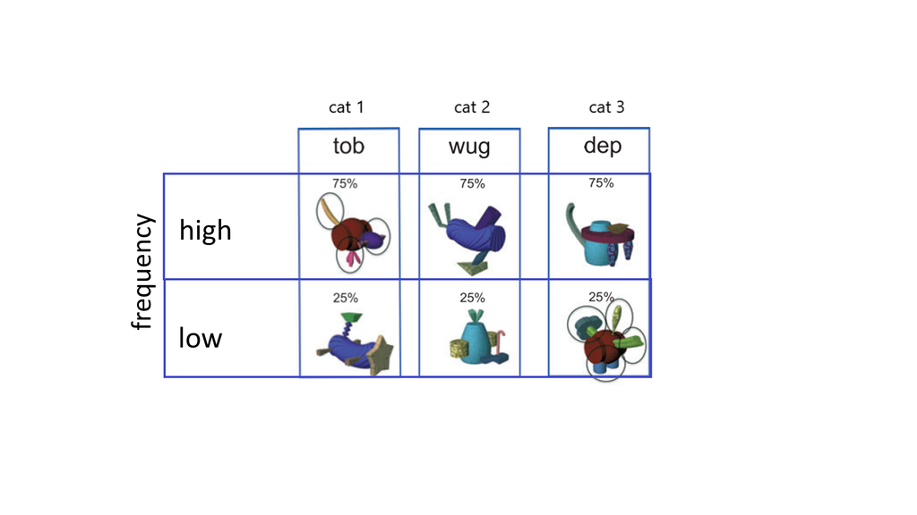

## beta estimates from Ramscar’s pilot

Our predicted effect sizes for the 2AFC tasks are based on data from an unpublished study that replicates Ramscar et al., (2010) effects. For the contingency judgment task instead we use our own pilot data.

We use for further analysis of the Bayes Factor the betas extracted from the model.

These are the betas of the models ran on Ramscar’s pilot data that we specify as theory in our Bayes Factor function:

- frequency: $\beta$ =-1.7 Note that this is negative.
- learning: $\beta$ =0.66
- interaction between learning and frequency: $\beta$ =1.03
- simple effect of low frequency: $\beta$ =1.18
- simple effect of high frequency: $\beta$ =0.15

These instead are the betas of the models ran on our pilot data of the contingency judgment task: From our pilot data:

- main effect of type: $\beta$ =53.78
- main effect of frequency by type: $\beta$ =83.618
- simple effect of learning by frequency - high match: $\beta$ =16
- simple effect of learning by frequency - low match: $\beta$ =-16
- simple effect of learning by frequency - high mismatch: $\beta$ =16
- simple effect of learning by frequency - low mismatch: $\beta$ =16

## Overview of the experiments

Although all the three experiments aim to exactly replicate the original methods, they differ from the original in the way some details have been carried out online. These differences, although in principle they should not have impacted the result of the experiments, we think contributed to making the picture of the results unclear. Attempt after attempt we worked hard to minimize the differences with the original paper.

- in experiment 1 the labels that were to be associated with the objects were presented in isolation and only auditorily, rather than written on the monitor and accompanied by a carrier sentence (FL: “that was a ..X”; LF: “this is a..X”). This made the processing of the stimuli temporally different from the original, giving potentially much more time to process the labels in the visual modality. Moreover, the two tests that were to test generalization of the label-object association were administered to all subjects, instead of being randomly assigned between participants like in the original study. Given the within participants choice of testing, the number of trials making up each of the tests was also lower: 28 rather than 56. Finally, we did not implement the control condition used in the original study to filter out bad subjects, but relied on performance on an unrelated attention check to reject participants. Results were confirmed in one task, but the evidence for our hypothesis was only anecdotal (BF = 2.8) and results in one condition (the high frequency) did not resemble the original with participants performing worse. We began to suspect that our design was too far from the original.
- in experiment 2 we tried to remedy these deviations by creating an experiment that was as faithful to the original as possible. We restored the written presentation of the labels and we reintroduced the between participants testing with the correct number of trials. Finally, we reintroduced the control condition (blue bims) so that we could apply the same exclusion criterion as the original study. The results if on the one hand in one condition (the high frequency) began to emulate the original ones, on the other hand they took a strange turn showing that all our participants could not even reach on average the chance level in the low frequency condition. These results made us think that the experiment had for some reason become extremely difficult to the point of making our participants worse. Furthermore, given the enormous individual variability, we began to suspect that the quality of our online data collection had drastically decreased. We realized that we did not check that the size of the stimuli (both labels and objects) was constant and identical for all subjects’ monitors. Most likely, the combination of the difficult condition (low frequency) and the poor visibility of the stimuli, additionally presented for a very short period (about 175 ms) created a lethal combination so that participants had experienced difficulty in seeing our stimuli. These considerations made us doubting (1) the way we presented the stimuli and (2) the quality of online data collection.
- to remedy the stimuli size confound, in experiment 3 we introduced an initial calibration that allowed subjects to view stimuli at a fixed aspect ratio. No other changes to our methods have been implemented in order to isolate the problem. We do, however, switched to an hybrid method of online data collection whereby instead of releasing our experiment in the wild, we asked a bunch of university students to take our experiment. These were informed that none of them could have been traced back, and they had to run the experiment in the privacy of their homes. The results of this last experiment confirm those obtained in the original paper and the evidence in favor of these is substantial (BF = 5.74). It remained to be seen though if this last version of the experiment is the winner because of the students we recruited, who could have been particularly motivated given their course of study, or because of the control of the stimulus presentation dimension.
- Experiment 3bis is the continuation of experiment 3, but this time we opened the data collection to Prolific. There were no other changes to this experiment.
- In Experiment 4 we have merged the data from experiment 3 and 3bis.

The table below attemps to summarise the differences between the three experiments:

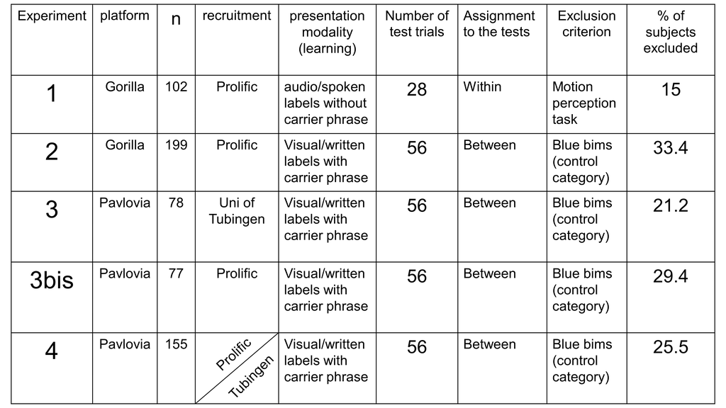

# Ramscar et al., (2010) results

```r
#center variables, we don't have NAs so I'm using lizCenter
fmri<-lizCenter(fmri, listfname = list("learning", "frequency"))

## --------------------------------- original model ------------------------------------##
fmriglmer1_V1<-glmer(acc ~  frequency.ct*learning.ct + (frequency.ct|subjID),
                     data = fmri,
                     family="binomial",
                     control=glmerControl(optimizer = "bobyqa"))
```

```
##                          Estimate Std. Error z value Pr(>|z|)
## (Intercept)                1.6099     0.1891  8.5141    0e+00
## frequency.ct              -1.7025     0.2483 -6.8554    0e+00
## learning.ct                0.6626     0.1360  4.8710    0e+00
## frequency.ct:learning.ct   1.0265     0.2615  3.9252    1e-04
```

```r
## --------------------------------- simple effects ------------------------------------##
fmriglmer1_V2<-glmer(acc ~  frequency.ct+ frequency: learning.ct + (frequency.ct|subjID),
                     data = fmri,
                     family="binomial",
                     control=glmerControl(optimizer = "bobyqa"))
```

```
##                        Estimate Std. Error z value Pr(>|z|)
## (Intercept)              1.6099     0.1891  8.5136   0.0000
## frequency.ct            -1.7025     0.2483 -6.8552   0.0000
## frequencyh:learning.ct   0.1493     0.2150  0.6947   0.4872
## frequencyl:learning.ct   1.1758     0.1581  7.4372   0.0000
```

#### plot Ramscar’s data

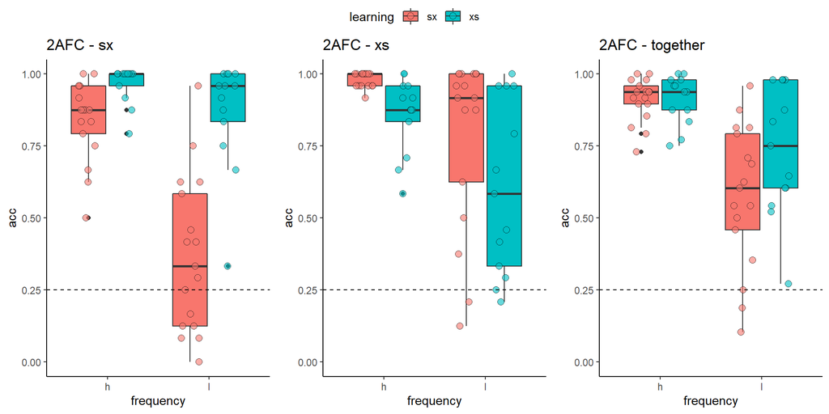

# Analysis template and Hypotheses

For the 2-AFC tasks we run generalised linear mixed effects models (GLMEs) including frequency and learning conditions as fixed effects, with a random intercept by participants and a random by participants slope for frequency. Before running the models, we always center the variables of interest by using a custom function ([lizCenter.R](https://n400peanuts.github.io/languagelearninglab/usefulFunctions-explained.html#lizCenter)). Note that we run separate analysis for each test, and a comprehensive analysis where we merge both tests together as in the original Ramscar’s analysis.

Hypothesis for both 2-AFC tasks:

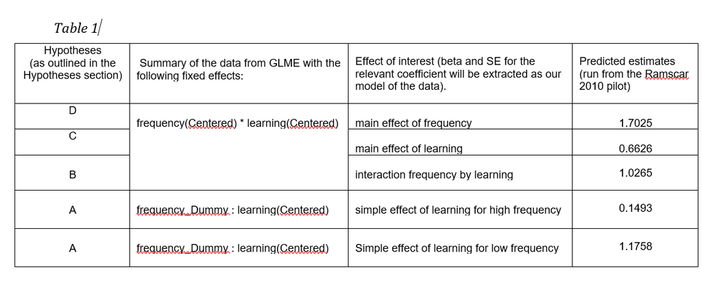

For the contingency judgment task we run a linear mixed effect model (LMER) where we specify learning-condition, match-type, and frequency condition as fixed effects. Random by participant effects are included for frequency, match type and frequency by match type.

Hypothesis for the contingency judgment task:

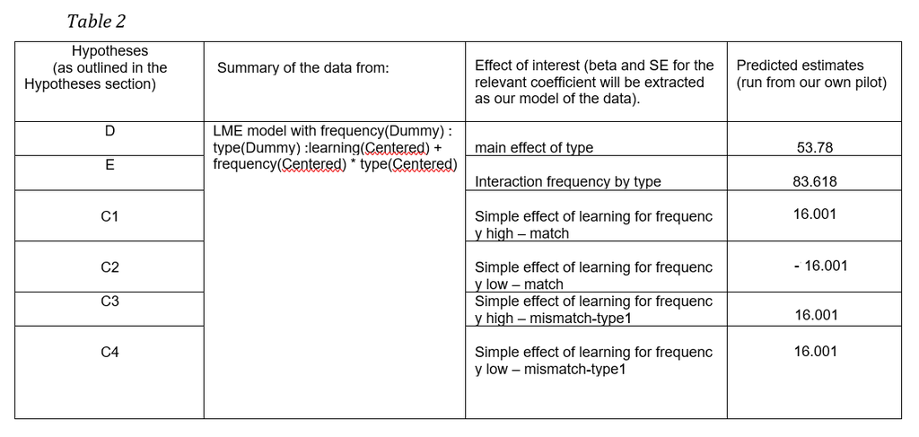

# Results

## Experiment 1

We calculate number of timeouts and average accuracy for the random dot task.

We excluded participants that made more than 3 timeout during learning, and/or that scored less than 70% accuracy in the random dot task.

### raw means

How many participants do we have at the net of the exclusion criterion?

We have 102 participants in total. 55 for feature-label learning, and 47 for label-feature learning.

We have excluded the 15% of the total.

### 2AFC - 4 Labels task

In this task participants see one picture and have to choose the correct label among 4 candidates (dep,tob,wug,bim).

Key predictions are: 1) interaction between frequency and condition 2) FL > LF for low frequency

Secondary predictions: 3) main effect of frequency (note- will almost certainly find this, but it isn’t key to our hypotheses) 4) main effect of FL> LF

```r
picLab_expe1_clean$learning<- relevel(picLab_expe1_clean$learning, ref = "LF")
picLab_expe1_clean$frequency<- relevel(picLab_expe1_clean$frequency, ref = "high")

picLab_expe1_clean<-lizCenter(picLab_expe1_clean, listfname = list("learning", "frequency"))

repFLO<-glmer(acc ~  frequency.ct*learning.ct + (frequency.ct|subjID),
              data = picLab_expe1_clean,
              family="binomial",
              control=glmerControl(optimizer = "bobyqa"))

output <- round(summary(repFLO)$coefficients,4)
output
```

```
##                          Estimate Std. Error z value Pr(>|z|)
## (Intercept)                0.1778     0.1102  1.6137   0.1066
## frequency.ct              -1.2389     0.2102 -5.8927   0.0000
## learning.ct                0.5009     0.2199  2.2778   0.0227
## frequency.ct:learning.ct   0.1295     0.4192  0.3090   0.7573
```

- hypothesis D) **Higher accuracy in the high vs low frequency condition as evidenced by a main effect of frequency.**
- beta of the theory: 1.7
- beta of the current model: -1.23 (std.error = .21)

BF for frequency:

```
## [1] 6588159
```

- hypothesis C) **higher accuracy in the feature-label learning condition, compared to label-feature learning-condition, as evidenced by a main effect of learning-condition.**
- beta of the theory: .66
- beta of the current model: 0.5 (std.error = .21)

BF for learning:

```
## [1] 6.419798
```

- hypothesis B) **A greater benefit of feature-label over label-feature for low frequency than for high frequency items, as evidenced by an interaction between frequency and learning-condition.**
- beta of the theory: 1.02
- beta of the current model: 0.129 (std.error = .41)

BF for the interaction between frequency and learning:

```
## [1] 0.4821975
```

MODEL 2 FOR SIMPLE EFFECTS:

```r
repFLO_V2<-glmer(acc ~  frequency.ct+ frequency: learning.ct + (frequency.ct|subjID),
                 data = picLab_expe1_clean,
                 family="binomial",
                 control=glmerControl(optimizer = "bobyqa"))

output_simpleEffect <- round(summary(repFLO_V2)$coefficients,4)
output_simpleEffect
```

```
##                           Estimate Std. Error z value Pr(>|z|)
## (Intercept)                 0.1778     0.1102  1.6137   0.1066
## frequency.ct               -1.2389     0.2102 -5.8928   0.0000
## frequencyhigh:learning.ct   0.4361     0.3204  1.3612   0.1735
## frequencylow:learning.ct    0.5656     0.2862  1.9763   0.0481
```

- hypothesis A.1) **Higher accuracy in the low frequency condition for the feature-label learning group compared to label-feature learning group, as evidenced by an effect of training-conditions for low-frequency test items.**
- beta of the theory: 1.17
- beta of the current model: 0.56 (std.error = .28)

BF for simple effect of learning for low frequency items:

```
## [1] 2.895542
```

- hypothesis A.2) **Related to the hypothesis above, we test also whether there is an effect of training-conditions for high-frequency test items.**
- beta of the theory: .14
- beta of the current model: 0.43 (std.error = .32)

BF for simple effect of learning for high frequency items:

```
## [1] 1.535259
```

### 2AFC - 4 Pictures task

In this task participants had to choose the correct picture among 4 candidates for one label presented.

Key predictions are: 1) interaction between frequency and condition 2) FL > LF for low frequency

Secondary predictions: 3) main effect of frequency (note- will almost certainly find this, but it isn’t key to our hypotheses) 4) main effect of FL> LF

```r
#-----1422680 and 1432009 must be added to the black list because have very few correct trials (less than a 1/3).---#

c(badsubjs, 1422680, 1432009) -> badsubjs
```

```r
labPic_expe1_clean$learning<- relevel(labPic_expe1_clean$learning, ref = "LF")
labPic_expe1_clean$frequency<- relevel(labPic_expe1_clean$frequency, ref = "high")

labPic_expe1_clean<-lizCenter(labPic_expe1_clean, listfname = list("learning", "frequency"))

repFLO<-glmer(acc ~  frequency.ct*learning.ct + (frequency.ct|subjID),
              data = labPic_expe1_clean,
              family="binomial",
              control=glmerControl(optimizer = "bobyqa"))

output <- round(summary(repFLO)$coefficients,4)
output
```

```
##                          Estimate Std. Error z value Pr(>|z|)
## (Intercept)                0.5352     0.1577  3.3942   0.0007
## frequency.ct              -1.9543     0.3212 -6.0838   0.0000
## learning.ct                0.4561     0.3108  1.4675   0.1422
## frequency.ct:learning.ct  -0.5795     0.6343 -0.9137   0.3609
```

- hypothesis D) **Higher accuracy in the high vs low frequency condition as evidenced by a main effect of frequency.**
- beta of the theory: 1.7
- beta of the current model: -1.95 (std.error = .32)

BF for frequency:

```
## [1] 21403861
```

- hypothesis C) **higher accuracy in the feature-label learning condition, compared to label-feature learning-condition, as evidenced by a main effect of learning-condition.**
- beta of the theory: .66
- beta of the current model: .45 (std.error = .31)

BF for learning:

```
## [1] 1.865734
```

- hypothesis B) **A greater benefit of feature-label over label-feature for low frequency than for high frequency items, as evidenced by an interaction between frequency and learning-condition.**
- beta of the theory: 1.02
- beta of the current model: -.57 (std.error = .63) #note here I use (main_effect) not (main_effect)*-1

BF for the interaction between frequency and learning:

```
## [1] 0.3112213
```

MODEL 2 FOR SIMPLE EFFECTS:

```r
repFLO_V2<-glmer(acc ~  frequency.ct+ frequency: learning.ct + (frequency.ct|subjID),
                 data = labPic_expe1_clean,
                 family="binomial",
                 control=glmerControl(optimizer = "bobyqa"))

output_simpleEffect <- round(summary(repFLO_V2)$coefficients,4)
output_simpleEffect
```

```
##                           Estimate Std. Error z value Pr(>|z|)
## (Intercept)                 0.5352     0.1577  3.3942   0.0007
## frequency.ct               -1.9543     0.3212 -6.0840   0.0000
## frequencyhigh:learning.ct   0.7404     0.4475  1.6544   0.0980
## frequencylow:learning.ct    0.1609     0.4402  0.3654   0.7148
```

- hypothesis A.1) **Higher accuracy in the low frequency condition for the feature-label learning group compared to label-feature learning group, as evidenced by an effect of training-conditions for low-frequency test items.**
- beta of the theory: 1.17
- beta of the current model: 0.16 (std.error = .44)

BF for simple effect of learning for low frequency items:

```
## [1] 0.4710121
```

- hypothesis A.2) **Related to the hypothesis above, we test also whether there is an effect of training-conditions for high-frequency test items.**
- beta of the theory: .14
- beta of the current model: 0.74 (std.error = .44)

BF for simple effect of learning for high frequency items:

```
## [1] 1.52426
```

### Both 2AFC tasks together

```r
FLO_tasks_expe1$learning<- relevel(FLO_tasks_expe1$learning, ref = "LF")
FLO_tasks_expe1$frequency<- relevel(FLO_tasks_expe1$frequency, ref = "high")

FLO_tasks_expe1<-lizCenter(FLO_tasks_expe1, listfname = list("learning", "frequency"))

repFLO<-glmer(acc ~  frequency.ct*learning.ct + (frequency.ct|subjID),
              data = FLO_tasks_expe1,
              family="binomial",
              control=glmerControl(optimizer = "bobyqa"))

output <- round(summary(repFLO)$coefficients,4)
output
```

```
##                          Estimate Std. Error z value Pr(>|z|)
## (Intercept)                0.3177     0.1203  2.6403   0.0083
## frequency.ct              -1.4933     0.2345 -6.3685   0.0000
## learning.ct                0.4720     0.2403  1.9645   0.0495
## frequency.ct:learning.ct  -0.2216     0.4681 -0.4734   0.6359
```

FOCUS ON HYPOTHESES B and A.1 and A.2:

hypothesis B) A greater benefit of feature-label over label-feature for low frequency than for high frequency items, as evidenced by an interaction between frequency and learning-condition.

beta of the theory: 1.02

beta of the current model: -.22 (std.error = .46) #note that I don’t change the sign in (main_effect)

BF for the interaction between frequency and learning:

BF for the interaction between learning and frequency:

```
## [1] 0.6062144
```

```r
repFLO_V2<-glmer(acc ~  frequency.ct+ frequency: learning.ct  + (frequency.ct|subjID),
                 data = FLO_tasks_expe1,
                 family="binomial",
                 control=glmerControl(optimizer = "bobyqa"))

output_simpleEffect <- round(summary(repFLO_V2)$coefficients,4)
output_simpleEffect
```

```
##                           Estimate Std. Error z value Pr(>|z|)
## (Intercept)                 0.3177     0.1203  2.6403   0.0083
## frequency.ct               -1.4933     0.2345 -6.3684   0.0000
## frequencyhigh:learning.ct   0.5818     0.3382  1.7200   0.0854
## frequencylow:learning.ct    0.3602     0.3326  1.0830   0.2788
```

hypothesis A.1) **Higher accuracy in the low frequency condition for the feature-label learning group compared to label-feature learning group, as evidenced by an effect of training-conditions for low-frequency test items**.

beta of the theory: 1.17

beta of the current model: .36 (std.error = .33)

BF for simple effect of learning for low frequency items:

[output not shown]

hypothesis A.2) **Related to the hypothesis above, we test also whether there is an effect of training-conditions for high-frequency test items.**.

beta of the theory: .14

beta of the current model: .58 (std.error = .33)

BF for simple effect of learning for high frequency items:

```
## [1] 0.5668926
```

### contingency task

For this task we are interested in just the match + mismatch_type1 data, and the following predictions:

The predictions are:

1. high: match: higher positive weight in LF (+ve coefficient) [LARGER EFFECT]
2. low match: higher positive weight in FL (-ve coeffficient) [SMALLER EFFECT]
3. high mismatch type 1: FL larger negative weight than LF (+ve coefficient)
4. low mismatch type 1: FL larger negative weight, LF positive (+ve coefficient) [LARGER EFFECT]

All of these are predicted from the computational model - however it is most likley that we will see the effects in (1) and (4) since these are largest.

### Plot experiment 1

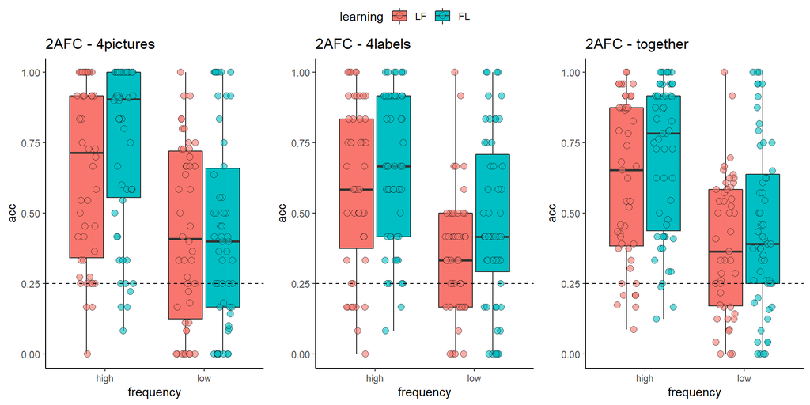

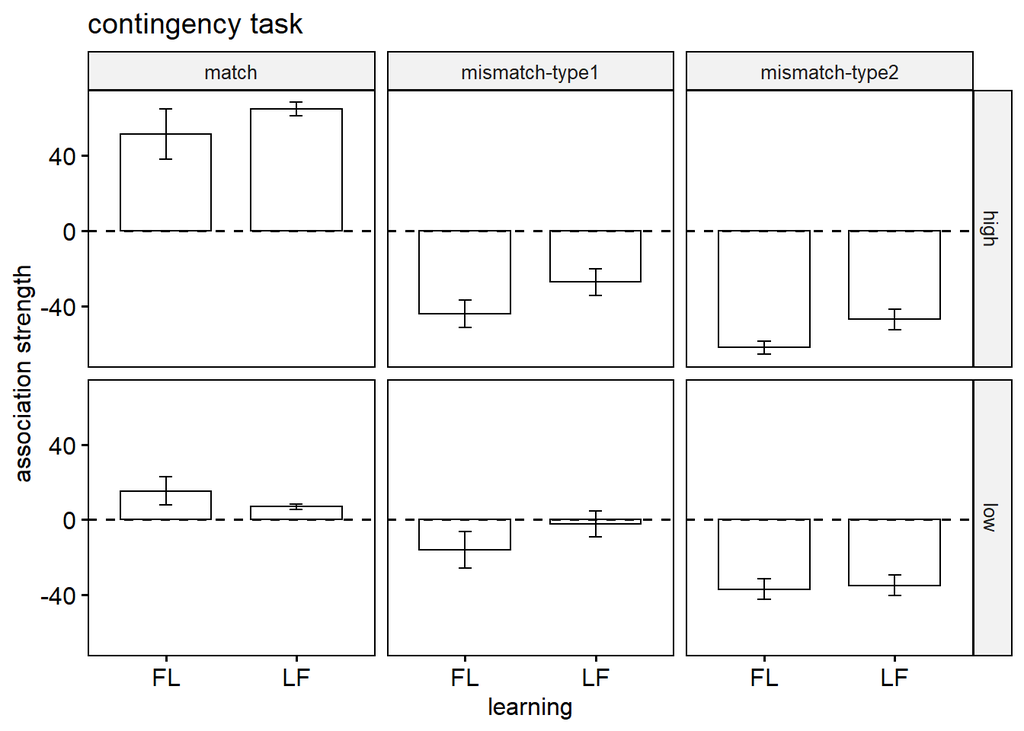

## Experiment 2

We exclude participants that score less than 80% in the control category (blue bims)

### raw means

How many participants do we have at the net of the exclusion criterion?

We have 199 participants in total. 99 for feature-label learning, and 100 for label-feature learning. We have excluded the 33.4% of the total.

### 2AFC- 4 labels task

In this task participants see one picture and have to choose the correct label among 4 candidates (dep,tob,wug,bim).

Key predictions are: 1) interaction between frequency and condition 2) FL > LF for low frequency

Secondary predictions: 3) main effect of frequency (note- will almost certainly find this, but it isn’t key to our hypotheses) 4) main effect of FL> LF

```r
picLab_expe2_clean$learning<- relevel(picLab_expe2_clean$learning, ref = "LF")
picLab_expe2_clean$correctFrequency<- relevel(picLab_expe2_clean$correctFrequency, ref = "high")

picLab_expe2_clean<-lizCenter(picLab_expe2_clean, listfname = list("learning", "correctFrequency"))

repFLO<-glmer(acc ~  correctFrequency.ct*learning.ct + (correctFrequency.ct|subjID),
              data = picLab_expe2_clean,
              family="binomial",
              control=glmerControl(optimizer = "bobyqa"))

output <- round(summary(repFLO)$coefficients,4)
output
```

```
##                                 Estimate Std. Error  z value Pr(>|z|)
## (Intercept)                       1.2291     0.2016   6.0982   0.0000
## correctFrequency.ct              -4.1936     0.3675 -11.4102   0.0000
## learning.ct                      -0.3331     0.3600  -0.9254   0.3547
## correctFrequency.ct:learning.ct  -0.4140     0.6401  -0.6468   0.5178
```

- hypothesis D) **Higher accuracy in the high vs low frequency condition as evidenced by a main effect of frequency.**
- beta of the theory: 1.7
- beta of the current model: -4.19 (std.error = .36)

BF for frequency:

```
## [1] 4.348894e+26
```

hypothesis C) **higher accuracy in the feature-label learning condition, compared to label-feature learning-condition, as evidenced by a main effect of learning-condition.**

beta of the theory: .66

beta of the current model: -0.33 (std.error = .36) #note here I don’t change sign in the BF formula

BF for learning:

```
## [1] 0.2789151
```

- hypothesis B) **A greater benefit of feature-label over label-feature for low frequency than for high frequency items, as evidenced by an interaction between frequency and learning-condition.**
- beta of the theory: 1.02
- beta of the current model: -0.41 (std.error = .62) #note here I don’t change sign in the BF formula

BF for the interaction between learning and frequency:

```
## [1] 0.3589859
```

MODEL 2 FOR SIMPLE EFFECTS:

```r
repFLO_V2<-glmer(acc ~  correctFrequency.ct+ correctFrequency: learning.ct + (correctFrequency.ct|subjID),
                 data = picLab_expe2_clean,
                 family="binomial",
                 control=glmerControl(optimizer = "bobyqa"))

output_simpleEffect <- round(summary(repFLO_V2)$coefficients,4)
output_simpleEffect
```

```
##                                  Estimate Std. Error  z value Pr(>|z|)
## (Intercept)                        1.2291     0.2016   6.0983   0.0000
## correctFrequency.ct               -4.1936     0.3675 -11.4098   0.0000
## correctFrequencyhigh:learning.ct  -0.1261     0.5726  -0.2203   0.8257
## correctFrequencylow:learning.ct   -0.5401     0.3691  -1.4632   0.1434
```

- hypothesis A.1) **Higher accuracy in the low frequency condition for the feature-label learning group compared to label-feature learning group, as evidenced by an effect of training-conditions for low-frequency test items.**
- beta of the theory: 1.17
- beta of the current model: -0.54 (std.error = .36)

BF for simple effect of learning for low frequency items:

```
## [1] 0.1304153
```

- hypothesis A.2) ** Related to the hypothesis above, we test also whether there is an effect of training-conditions for high-frequency test items.**
- beta of the theory: .14
- beta of the current model: -0.12 (std.error = .57)

BF for simple effect of learning for high frequency items:

```
## [1] 0.9258948
```

### 2AFC- 4pictures task

```r
labPic_expe2_clean$learning<- relevel(labPic_expe2_clean$learning, ref = "LF")
labPic_expe2_clean$correctFrequency<- relevel(labPic_expe2_clean$correctFrequency, ref = "high")

labPic_expe2_clean<-lizCenter(labPic_expe2_clean, listfname = list("learning", "correctFrequency"))

repFLO<-glmer(acc ~  correctFrequency.ct*learning.ct + (correctFrequency.ct|subjID),
              data = labPic_expe2_clean,
              family="binomial",
              control=glmerControl(optimizer = "bobyqa"))

output <- round(summary(repFLO)$coefficients,4)
output
```

```
##                                 Estimate Std. Error  z value Pr(>|z|)
## (Intercept)                       0.3425     0.1256   2.7259   0.0064
## correctFrequency.ct              -3.7835     0.2779 -13.6149   0.0000
## learning.ct                       0.0111     0.2443   0.0452   0.9639
## correctFrequency.ct:learning.ct   0.4873     0.5437   0.8963   0.3701
```

- hypothesis D) **Higher accuracy in the high vs low frequency condition as evidenced by a main effect of frequency.**
- beta of the theory: 1.7
- beta of the current model: -3.78 (std.error = .27)

BF for frequency:

```
## [1] 5.130724e+38
```

- hypothesis C) **higher accuracy in the feature-label learning condition, compared to label-feature learning-condition, as evidenced by a main effect of learning-condition.**
- beta of the theory: .66
- beta of the current model: 0.01 (std.error = .24)

BF for learning:

```
## [1] 0.3605336
```

- hypothesis B) **A greater benefit of feature-label over label-feature for low frequency than for high frequency items, as evidenced by an interaction between frequency and learning-condition.**
- beta of the theory: 1.02
- beta of the current model: 0.48 (std.error = .54)

BF for the interaction between learning and frequency:

```
## [1] 1.004651
```

MODEL 2 FOR SIMPLE EFFECTS:

```r
repFLO_V2<-glmer(acc ~  correctFrequency.ct+ correctFrequency: learning.ct + (correctFrequency.ct|subjID),
                 data = labPic_expe2_clean,
                 family="binomial",
                 control=glmerControl(optimizer = "bobyqa"))

output_simpleEffect <- round(summary(repFLO_V2)$coefficients,4)
output_simpleEffect
```

```
##                                  Estimate Std. Error  z value Pr(>|z|)
## (Intercept)                        0.3425     0.1256   2.7258   0.0064
## correctFrequency.ct               -3.7835     0.2779 -13.6136   0.0000
## correctFrequencyhigh:learning.ct  -0.2326     0.4046  -0.5749   0.5654
## correctFrequencylow:learning.ct    0.2547     0.3217   0.7917   0.4285
```

- hypothesis A.1) Higher accuracy in the low frequency condition for the feature-label learning group compared to label-feature learning group, as evidenced by an effect of training-conditions for low-frequency test items.
- beta of the theory: 1.17
- beta of the current model: 0.25 (std.error = .32)

BF for simple effect of learning for low frequency items:

```
## [1] 0.5484706
```

- hypothesis A.2) **Related to the hypothesis above, we test also whether there is an effect of training-conditions for high-frequency test items.**
- beta of the theory: .14
- beta of the current model: -0.23 (std.error = .4)

BF for simple effect of learning for high frequency items:

```
## [1] 0.8054242
```

### Both 2AFC tasks together

```r
FLO_tasks_expe2$learning<- relevel(FLO_tasks_expe2$learning, ref = "LF")
FLO_tasks_expe2$correctFrequency<- relevel(FLO_tasks_expe2$correctFrequency, ref = "high")

FLO_tasks_expe2<-lizCenter(FLO_tasks_expe2, listfname = list("learning", "correctFrequency"))

repFLO<-glmer(acc ~  correctFrequency.ct*learning.ct + (correctFrequency.ct|subjID),
              data = FLO_tasks_expe2,
              family="binomial",
              control=glmerControl(optimizer = "bobyqa"))

output <- round(summary(repFLO)$coefficients,4)
output
```

```
##                                 Estimate Std. Error  z value Pr(>|z|)
## (Intercept)                       0.7540     0.1163   6.4819   0.0000
## correctFrequency.ct              -3.9388     0.2220 -17.7403   0.0000
## learning.ct                      -0.1410     0.2180  -0.6470   0.5177
## correctFrequency.ct:learning.ct  -0.0033     0.4141  -0.0080   0.9936
```

- hypothesis B) **A greater benefit of feature-label over label-feature for low frequency than for high frequency items, as evidenced by an interaction between frequency and learning-condition.**
- beta of the theory: 1.02
- beta of the current model: -0.0033 (std.error = .41)

BF for the interaction between learning and frequency:

```
## [1] 0.3764754
```

MODEL 2 FOR SIMPLE EFFECTS:

```r
repFLO_V2<-glmer(acc ~  correctFrequency.ct+ correctFrequency: learning.ct  + (correctFrequency.ct|subjID),
                 data = FLO_tasks_expe2,
                 family="binomial",
                 control=glmerControl(optimizer = "bobyqa"))

output_simpleEffect <- round(summary(repFLO_V2)$coefficients,4)
output_simpleEffect
```

```
##                                  Estimate Std. Error  z value Pr(>|z|)
## (Intercept)                        0.7540     0.1163   6.4813   0.0000
## correctFrequency.ct               -3.9388     0.2221 -17.7357   0.0000
## correctFrequencyhigh:learning.ct  -0.1394     0.3426  -0.4069   0.6841
## correctFrequencylow:learning.ct   -0.1427     0.2524  -0.5653   0.5719
```

- hypothesis A.1) **Higher accuracy in the low frequency condition for the feature-label learning group compared to label-feature learning group, as evidenced by an effect of training-conditions for low-frequency test items.**
- beta of the theory: 1.17
- beta of the current model: -0.14 (std.error = .25) #(note the opposite direction)

BF for simple effect of learning for low frequency items:

```
## [1] 0.3472738
```

hypothesis A.2) Related to the hypothesis above, we test also whether there is an effect of training-conditions for high-frequency test items.

beta of the theory: .14

beta of the current model: -0.13 (std.error = .34)

BF for simple effect of learning for high frequency items:

```
## [1] 1.04857
```

### contingency task

The possible label-fribble combinations are of two types:

- match: label-fribble pair presented is 100% correct for both high and low frequency conditions.
- mismatch: Items label is incorrect for this fribble type but the fribble has a high salience feature (shape) which is with the label.

For this task we are interested in just the match + mismatch data, and the following predictions:

The predictions are:

1. high: match: higher positive weight in LF (+ve coefficient) [LARGER EFFECT]
2. low match: higher positive weight in FL (-ve coeffficient) [SMALLER EFFECT]
3. high mismatch: FL larger negative weight than LF (+ve coefficient)
4. low mismatch: FL larger negative weight, LF positive (+ve coefficient) [LARGER EFFECT]

All of these are predicted from the computational model - however it is most likely that we will see the effects in (1) and (4) since these are largest.

```r
relevel(contingency_expe2_clean$trialType, ref = "mismatch-type1")->contingency_expe2_clean$trialType
relevel(contingency_expe2_clean$learning, ref = "LF")->contingency_expe2_clean$learning
relevel(contingency_expe2_clean$frequency, ref = "l")->contingency_expe2_clean$frequency

contingency_expe2_clean<-lizCenter(contingency_expe2_clean, listfname = list("learning", "frequency", "trialType"))

lm1<- lmerTest::lmer(resp ~  frequency:trialType:learning.ct + frequency.ct * trialType.ct  + (1|subjID)  , data = contingency_expe2_clean)
car::Anova(lm1)
```

```
## Analysis of Deviance Table (Type II Wald chisquare tests)
##
## Response: resp
##                                    Chisq Df Pr(>Chisq)
## frequency.ct                      16.255  1  5.537e-05 ***
## trialType.ct                    1471.591  1  < 2.2e-16 ***
## frequency.ct:trialType.ct       4970.110  1  < 2.2e-16 ***
## frequency:trialType:learning.ct   19.961  4  0.0005083 ***
## ---
## Signif. codes:  0 '***' 0.001 '**' 0.01 '*' 0.05 '.' 0.1 ' ' 1
```

```r
output<-round(summary(lm1)$coefficients,4)
output_contingency<-round(summary(lm1)$coefficients,4)

kableExtra::kable(output)
```

|  | Estimate | Std. Error | df | t value | Pr(>\|t\|) |
| --- | --- | --- | --- | --- | --- |
| (Intercept) | -1.1257 | 0.8725 | 191.2189 | -1.2901 | 0.1986 |
| frequency.ct | 4.6258 | 1.1686 | 11469.3288 | 3.9585 | 0.0001 |
| trialType.ct | 44.7111 | 1.1686 | 11470.8200 | 38.2599 | 0.0000 |
| frequency.ct:trialType.ct | 164.7709 | 2.3372 | 11470.4983 | 70.4990 | 0.0000 |
| frequencyl:trialTypemismatch-type1:learning.ct | 9.4826 | 2.6753 | 1025.4356 | 3.5445 | 0.0004 |
| frequencyh:trialTypemismatch-type1:learning.ct | 3.8544 | 2.6721 | 1021.2065 | 1.4424 | 0.1495 |
| frequencyl:trialTypematch:learning.ct | -2.3379 | 2.6730 | 1022.2568 | -0.8746 | 0.3820 |
| frequencyh:trialTypematch:learning.ct | -2.8485 | 2.6702 | 1018.2649 | -1.0668 | 0.2863 |

BF for main effect of type:

```
## [1] Inf
```

- Hypothesis E) **Higher ratings for high frequency match- than low frequency match trials, but lower ratings for high frequency mismatch than low frequency mismatch, as evidenced by an interaction between frequency condition and type.**
- beta of the theory: 83.61 #note here I reverse the sign with *-1
- beta of the current model: 164.7709 (std.error = 2.33)

BF for interaction between frequency x type:

```
## [1] Inf
```

- Hypothesis C.1) **High frequency – match: stronger learning- in label-feature (evidenced by positive effect of learning-condition i.e. higher ratings in label feature than feature label))**
- beta of the theory: 16
- beta of the current model: -2.84 (std.error = 2.67) #don’t change sign in the formula

BF for simple effect of high frequency x match:

```
## [1] 0.08564476
```

- hypothesis C.2) **Low frequency – match: stronger learning in feature-label (evidenced by negative effect of learning-condition i.e. higher ratings in feature-label feature).**
- beta of the theory: -16 (note negative sign)
- beta of the current model: -2.33 (std.error = 2.67)

BF for simple effect of low frequency x match:

```
## [1] 0.3865038
```

- Hypothesis C.3) **High frequency – mismatch-type: stronger learning in feature-label (evidenced by positive effect of learning-condition i.e. higher ratings in label-feature than feature-label).**
- beta of the theory: 16
- beta of the current model: 3.85 (std.error = 2.67)

BF for simple effect of high frequency x mismatch:

```
## [1] 0.836604
```

- Hypothesis C.4) **Low frequency – mismatch-type: stronger learning in feature-label (evidenced by positive effect of learning-condition i.e. higher ratings in label-feature than feature-label).**
- beta of the theory: 16
- beta of the current model: 9.48 (std.error = 2.67)

BF for simple effect of low frequency x mismatch:

```
## [1] 148.3402
```

### plot experiment 2

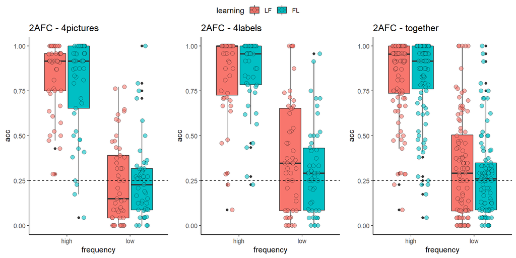

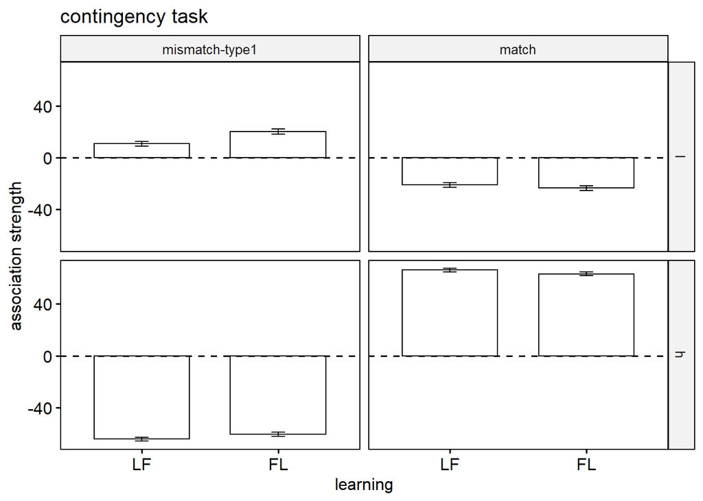

## Experiment 3

We exclude participants that score less than 80% in the control category (blue bims)

### raw means

How many participants do we have at the net of the exclusion criterion?

We have 78 participants in total. 44 for feature-label learning, and 34 for label-feature learning. We have excluded the 21.2 of the total.

### 2AFC- 4 labels task

In this task participants see one picture and have to choose the correct label among 4 candidates (dep,tob,wug,bim).

Key predictions are:

1. interaction between frequency and condition
2. FL > LF for low frequency

Secondary predictions:

3. main effect of frequency (note- will almost certainly find this, but it isn’t key to our hypotheses)
4. main effect of FL> LF

```r
picLab_expe3_clean$learning<- relevel(picLab_expe3_clean$learning, ref = "LF")
picLab_expe3_clean$correctFrequency<- relevel(picLab_expe3_clean$correctFrequency, ref = "high")

picLab_expe3_clean<-lizCenter(picLab_expe3_clean, listfname = list("learning", "correctFrequency"))

repFLO<-glmer(acc ~  correctFrequency.ct*learning.ct + (correctFrequency.ct|subjID),
              data = picLab_expe3_clean,
              family="binomial",
              control=glmerControl(optimizer = "bobyqa"))

output <- round(summary(repFLO)$coefficients,4)
output
```

```
##                                 Estimate Std. Error z value Pr(>|z|)
## (Intercept)                       1.3478     0.2350  5.7350   0.0000
## correctFrequency.ct              -1.8604     0.2092 -8.8920   0.0000
## learning.ct                      -0.0314     0.4426 -0.0709   0.9435
## correctFrequency.ct:learning.ct   0.0981     0.3860  0.2543   0.7993
```

- hypothesis D) **Higher accuracy in the high vs low frequency condition as evidenced by a main effect of frequency.**
- beta of the theory: 1.7
- beta of the current model: -1.86 (std.error = .20)

BF for frequency:

```
## [1] 2.012494e+16
```

- hypothesis C) **higher accuracy in the feature-label learning condition, compared to label-feature learning-condition, as evidenced by a main effect of learning-condition.**
- beta of the theory: .66
- beta of the current model: -0.03 (std.error = .44) #note opposite direction

BF for learning:

```
## [1] 0.5326485
```

- hypothesis B) **A greater benefit of feature-label over label-feature for low frequency than for high frequency items, as evidenced by an interaction between frequency and learning-condition.**
- beta of the theory: 1.02
- beta of the current model: 0.09 (std.error = .38)

BF for the interaction between frequency and learning:

```
## [1] 0.4300461
```

MODEL 2 FOR SIMPLE EFFECTS:

```r
repFLO_V2<-glmer(acc ~  correctFrequency.ct+ correctFrequency: learning.ct + (correctFrequency.ct|subjID),
                 data = picLab_expe3_clean,
                 family="binomial",
                 control=glmerControl(optimizer = "bobyqa"))

output_simpleEffect <- round(summary(repFLO_V2)$coefficients,4)
output_simpleEffect
```

```
##                                  Estimate Std. Error z value Pr(>|z|)
## (Intercept)                        1.3478     0.2350  5.7350   0.0000
## correctFrequency.ct               -1.8604     0.2092 -8.8920   0.0000
## correctFrequencyhigh:learning.ct  -0.1295     0.6771 -0.1913   0.8483
## correctFrequencylow:learning.ct    0.0668     0.4810  0.1389   0.8896
```

- hypothesis A.1) **Higher accuracy in the low frequency condition for the feature-label learning group compared to label-feature learning group, as evidenced by an effect of training-conditions for low-frequency test items.**
- beta of the theory: 1.17
- beta of the current model: 0.06 (std.error = .48)

BF for the simple effect of low frequency by learning:

```
## [1] 0.4207076
```

- hypothesis A.2) **Related to the hypothesis above, we test also whether there is an effect of training-conditions for high-frequency test items.**
- beta of the theory: .14
- beta of the current model: -0.12 (std.error = .67)

BF for the simple effect of high frequency by learning:

```
## [1] 0.9450317
```

### 2AFC- 4pictures task

In this task participants had to choose the correct picture among 4 candidates for one label presented.

Key predictions are:

1. interaction between frequency and condition
2. FL > LF for low frequency

Secondary predictions:

3. main effect of frequency (note- will almost certainly find this, but it isn’t key to our hypotheses)
4. main effect of FL> LF

```r
labPic_expe3_clean$learning<- relevel(labPic_expe3_clean$learning, ref = "LF")
labPic_expe3_clean$correctFrequency<- relevel(labPic_expe3_clean$correctFrequency, ref = "high")

labPic_expe3_clean<-lizCenter(labPic_expe3_clean, listfname = list("learning", "correctFrequency"))

repFLO<-glmer(acc ~  correctFrequency.ct*learning.ct + (correctFrequency.ct|subjID),
              data = labPic_expe3_clean,
              family="binomial",
              control=glmerControl(optimizer = "bobyqa"))

output <- round(summary(repFLO)$coefficients,4)
output
```

```
##                                 Estimate Std. Error z value Pr(>|z|)
## (Intercept)                       0.6630     0.2247  2.9501   0.0032
## correctFrequency.ct              -4.4237     0.4967 -8.9065   0.0000
## learning.ct                       1.0845     0.4307  2.5182   0.0118
## correctFrequency.ct:learning.ct   0.9069     0.9631  0.9416   0.3464
```

- hypothesis D) **Higher accuracy in the high vs low frequency condition as evidenced by a main effect of frequency.**
- beta of the theory: 1.7
- beta of the current model: -4.42 (std.error = .49)

BF for frequency:

```
## [1] 4.144076e+15
```

- hypothesis C) **higher accuracy in the feature-label learning condition, compared to label-feature learning-condition, as evidenced by a main effect of learning-condition.**
- beta of the theory: .66
- beta of the current model: 1.08 (std.error = .43)

BF for learning:

```
## [1] 9.902941
```

- hypothesis B) **A greater benefit of feature-label over label-feature for low frequency than for high frequency items, as evidenced by an interaction between frequency and learning-condition.**
- beta of the theory: 1.02
- beta of the current model: .90 (std.error = .96)

BF for the interaction between learning and frequency:

```
## [1] 1.304553
```

MODEL 2 FOR SIMPLE EFFECTS:

```r
repFLO_V2<-glmer(acc ~  correctFrequency.ct+ correctFrequency: learning.ct  + (correctFrequency.ct|subjID),
                 data = labPic_expe3_clean,
                 family="binomial",
                 control=glmerControl(optimizer = "bobyqa"))

output_simpleEffect <- round(summary(repFLO_V2)$coefficients,4)
output_simpleEffect
```

```
##                                  Estimate Std. Error z value Pr(>|z|)
## (Intercept)                        0.6630     0.2247  2.9501   0.0032
## correctFrequency.ct               -4.4237     0.4966 -8.9072   0.0000
## correctFrequencyhigh:learning.ct   0.6311     0.5814  1.0855   0.2777
## correctFrequencylow:learning.ct    1.5380     0.7047  2.1824   0.0291
```

- hypothesis A.1) **Higher accuracy in the low frequency condition for the feature-label learning group compared to label-feature learning group, as evidenced by an effect of training-conditions for low-frequency test items.**
- beta of the theory: 1.17
- beta of the current model: 1.53 (std.error = .70)

BF for the simple effect of learning for low frequency items:

```
## [1] 5.743435
```

- hypothesis A.2) **Related to the hypothesis above, we test also whether there is an effect of training-conditions for high-frequency test items.**
- beta of the theory: .14
- beta of the current model: 0.63 (std.error = .58)

BF for the simple effect of learning for high frequency items:

```
## [1] 1.218836
```

### Both 2AFC tasks together

```r
FLO_tasks_expe3$learning<- relevel(FLO_tasks_expe3$learning, ref = "LF")
FLO_tasks_expe3$correctFrequency<- relevel(FLO_tasks_expe3$correctFrequency, ref = "high")

FLO_tasks_expe3<-lizCenter(FLO_tasks_expe3, listfname = list("learning", "correctFrequency"))

repFLO<-glmer(acc ~  correctFrequency.ct*learning.ct + (correctFrequency.ct|subjID),
              data = FLO_tasks_expe3,
              family="binomial",
              control=glmerControl(optimizer = "bobyqa"))

output <- round(summary(repFLO)$coefficients,4)
output
```

```
##                                 Estimate Std. Error  z value Pr(>|z|)
## (Intercept)                       1.0703     0.1664   6.4336    0.000
## correctFrequency.ct              -3.9708     0.3160 -12.5664    0.000
## learning.ct                       0.4276     0.3175   1.3469    0.178
## correctFrequency.ct:learning.ct   0.4792     0.5993   0.7995    0.424
```

- hypothesis D) **Higher accuracy in the high vs low frequency condition as evidenced by a main effect of frequency.**
- beta of the theory: 1.7
- beta of the current model: -3.97 (std.error = .31)

BF for frequency:

```
## [1] 5.063029e+32
```

- hypothesis C) **higher accuracy in the feature-label learning condition, compared to label-feature learning-condition, as evidenced by a main effect of learning-condition.**
- beta of the theory: .66
- beta of the current model: .42 (std.error = .31)

BF for learning:

```
## [1] 1.605973
```

- hypothesis B) **A greater benefit of feature-label over label-feature for low frequency than for high frequency items, as evidenced by an interaction between frequency and learning-condition.**
- beta of the theory: 1.02
- beta of the current model: .47 (std.error = .59)

BF for the interaction between learning and frequency:

```
## [1] 0.9646439
```

MODEL 2 FOR SIMPLE EFFECTS:

```r
repFLO_V2<-glmer(acc ~  correctFrequency.ct+ correctFrequency: learning.ct  + (correctFrequency.ct|subjID),
                 data = FLO_tasks_expe3,
                 family="binomial",
                 control=glmerControl(optimizer = "bobyqa"))

output_simpleEffect <- round(summary(repFLO_V2)$coefficients,4)
output_simpleEffect
```

```
##                                  Estimate Std. Error  z value Pr(>|z|)
## (Intercept)                        1.0703     0.1664   6.4336   0.0000
## correctFrequency.ct               -3.9708     0.3160 -12.5657   0.0000
## correctFrequencyhigh:learning.ct   0.1880     0.4560   0.4123   0.6801
## correctFrequencylow:learning.ct    0.6672     0.4164   1.6023   0.1091
```

- hypothesis A.1) **Higher accuracy in the low frequency condition for the feature-label learning group compared to label-feature learning group, as evidenced by an effect of training-conditions for low-frequency test items.**
- beta of the theory: 1.17
- beta of the current model: 0.66 (std.error = .41)

BF of the simple effect of low frequency by learning:

```
## [1] 1.946005
```

- hypothesis A.2) **Related to the hypothesis above, we test also whether there is an effect of training-conditions for high-frequency test items.**
- beta of the theory: .14
- beta of the current model: 0.18 (std.error = .45)

BF of the simple effect of high frequency by learning:

```
## [1] 1.055914
```

### contingency task

The possible label-fribble combinations are of two types:

- match: label-fribble pair presented is 100% correct for both high and low frequency conditions.
- mismatch: Items label is incorrect for this fribble type but the fribble has a high salience feature (shape) which is with the label.

For this task we are interested in just the match + mismatch data, and the following predictions:

The predictions are:

1. high: match: higher positive weight in LF (+ve coefficient) [LARGER EFFECT]
2. low match: higher positive weight in FL (-ve coeffficient) [SMALLER EFFECT]
3. high mismatch: FL larger negative weight than LF (+ve coefficient)
4. low mismatch: FL larger negative weight, LF positive (+ve coefficient) [LARGER EFFECT]

All of these are predicted from the computational model - however it is most likely that we will see the effects in (1) and (4) since these are largest.

```r
contingency_expe3_clean$trialType<- as.factor(contingency_expe3_clean$trialType)
contingency_expe3_clean$frequency<- as.factor(contingency_expe3_clean$frequency)
contingency_expe3_clean$subjID<- as.factor(contingency_expe3_clean$subjID)
contingency_expe3_clean$fribbleID<- as.factor(contingency_expe3_clean$fribbleID)

relevel(contingency_expe3_clean$trialType, ref = "mismatch-type1")->contingency_expe3_clean$trialType
relevel(contingency_expe3_clean$learning, ref = "LF")->contingency_expe3_clean$learning
relevel(contingency_expe3_clean$frequency, ref = "l")->contingency_expe3_clean$frequency

contingency_expe3_clean<-lizCenter(contingency_expe3_clean, listfname = list("learning", "frequency", "trialType"))

lm1<- lmerTest::lmer(resp ~  frequency:trialType:learning + frequency.ct * trialType.ct  + (frequency.ct|subjID), data = contingency_expe3_clean)
```

```
## fixed-effect model matrix is rank deficient so dropping 4 columns / coefficients
```

```
## boundary (singular) fit: see ?isSingular
```

```r
car::Anova(lm1)
```

```
## Analysis of Deviance Table (Type II Wald chisquare tests)
##
## Response: resp
##                                  Chisq Df Pr(>Chisq)
## frequency.ct                    6.0767  1     0.0137 *
## trialType.ct                  926.0725  1  < 2.2e-16 ***
## frequency.ct:trialType.ct    1075.1276  1  < 2.2e-16 ***
## frequency:trialType:learning   50.0239  4   3.57e-10 ***
## ---
## Signif. codes:  0 '***' 0.001 '**' 0.01 '*' 0.05 '.' 0.1 ' ' 1
```

```r
output<-round(summary(lm1)$coefficients,4)
kableExtra::kable(output)
```

|  | Estimate | Std. Error | df | t value | Pr(>\|t\|) |
| --- | --- | --- | --- | --- | --- |
| (Intercept) | -2.2235 | 1.5111 | 85.4880 | -1.4715 | 0.1448 |
| frequency.ct | 6.5869 | 2.6096 | 207.0472 | 2.5241 | 0.0124 |
| trialType.ct | 73.5841 | 2.4396 | 4536.0459 | 30.1620 | 0.0000 |
| frequency.ct:trialType.ct | 159.9866 | 4.8793 | 4536.0697 | 32.7891 | 0.0000 |
| frequencyl:trialTypemismatch-type1:learningLF | 18.5566 | 4.2377 | 207.4763 | 4.3790 | 0.0000 |
| frequencyh:trialTypemismatch-type1:learningLF | 0.1244 | 3.7410 | 1267.8178 | 0.0333 | 0.9735 |
| frequencyl:trialTypematch:learningLF | -18.5279 | 4.2391 | 207.7572 | -4.3707 | 0.0000 |
| frequencyh:trialTypematch:learningLF | 0.5181 | 3.7434 | 1269.9840 | 0.1384 | 0.8900 |

- Hypothesis D) **Higher ratings for match compared to the mismatch trials.**

beta of the theory: 53.78

beta of the current model: 73.58 (std.error = 2.43)

BF for main effect of type:

```
## [1] 1.276713e+196
```

- Hypothesis E) **Higher ratings for high frequency match- than low frequency match trials, but lower ratings for high frequency mismatch than low frequency mismatch, as evidenced by an interaction between frequency condition and type.**
- beta of the theory: 83.61 #note here I reverse the sign with *-1
- beta of the current model: 159.98 (std.error = 4.87)

BF for interaction frequency by type:

```
## [1] 5.392521e+231
```

- Hypothesis C.1) **High frequency – match: stronger learning- in label-feature (evidenced by positive effect of learning-condition i.e. higher ratings in label feature than feature label))**
- beta of the theory: 16
- beta of the current model: .51 (std.error = 3.74)

BF for Simple effect of learning for frequency high - match:

```
## [1] 0.2560162
```

- hypothesis C.2) **Low frequency – match: stronger learning in feature-label (evidenced by negative effect of learning-condition i.e. higher ratings in feature-label feature).**
- beta of the theory: -16 (note negative sign)
- beta of the current model: -18.52 (std.error = 4.23)

BF Simple effect of learning for frequency low - match:

```
## [1] 3843.213
```

- Hypothesis C.3) **High frequency – mismatch-type: stronger learning in feature-label (evidenced by positive effect of learning-condition i.e. higher ratings in label-feature than feature-label).**
- beta of the theory: 16
- beta of the current model: 0.12 (std.error = 3.74)

BF Simple effect of learning for frequency high - mismatch:

```
## [1] 0.2352008
```

- Hypothesis C.4) **Low frequency – mismatch-type: stronger learning in feature-label (evidenced by positive effect of learning-condition i.e. higher ratings in label-feature than feature-label).**
- beta of the theory: 16
- beta of the current model: 18.55 (std.error = 4.23) #don’t change sign in the formula

BF Simple effect of learning for frequency low - mismatch:

```
## [1] 3974.808
```

### Plot experiment 3

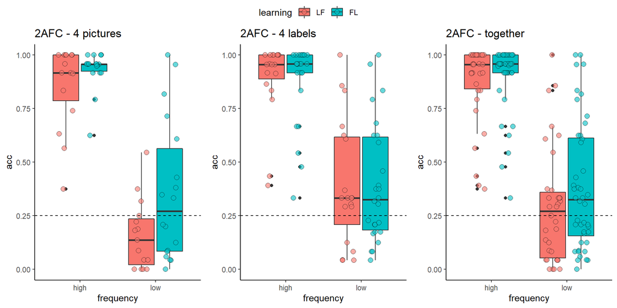

```r
contingency_expe3_clean %>%
  filter(generalizationTest=="labPic") %>%
  group_by(learning, frequency, trialType) %>%
  summarise(mean=mean(resp, na.rm = T),
            sd=sd(resp, na.rm = T),
            count = n()) %>%
  mutate(se = sd / sqrt(count),
         lower_ci = lower_ci(mean, se, count),
         upper_ci = upper_ci(mean, se, count))
```

```
## # A tibble: 8 x 9
## # Groups:   learning, frequency [4]
##   learning frequency trialType        mean    sd count    se lower_ci upper_ci
##   <fct>    <fct>     <fct>           <dbl> <dbl> <int> <dbl>    <dbl>    <dbl>
## 1 LF       l         mismatch-type1  32.3   63.9   225  4.26    23.9     40.7
## 2 LF       l         match          -42.9   67.6   225  4.51   -51.8    -34.0
## 3 LF       h         mismatch-type1 -74.7   49.3   225  3.29   -81.2    -68.2
## 4 LF       h         match           81.0   36.1   225  2.41    76.2     85.7
## 5 FL       l         mismatch-type1   1.54  74.1   270  4.51    -7.34    10.4
## 6 FL       l         match           -5.40  77.0   270  4.69   -14.6      3.83
## 7 FL       h         mismatch-type1 -80.8   40.7   270  2.48   -85.6    -75.9
## 8 FL       h         match           86.2   31.2   270  1.90    82.5     89.9
```

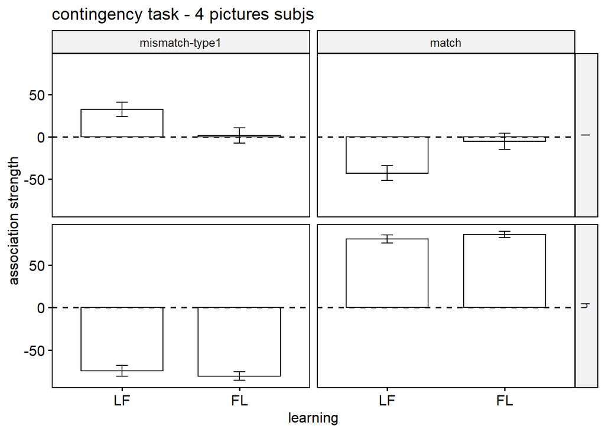

```r
contingency_expe3_clean %>%
  filter(generalizationTest=="picLab") %>%
  group_by(learning, frequency, trialType) %>%
  summarise(mean=mean(resp, na.rm = T),
            sd=sd(resp, na.rm = T),
            count = n()) %>%
  mutate(se = sd / sqrt(count),
         lower_ci = lower_ci(mean, se, count),
         upper_ci = upper_ci(mean, se, count))
```

```
## # A tibble: 8 x 9
## # Groups:   learning, frequency [4]
##   learning frequency trialType        mean    sd count    se lower_ci upper_ci
##   <fct>    <fct>     <fct>           <dbl> <dbl> <int> <dbl>    <dbl>    <dbl>
## 1 LF       l         mismatch-type1   3.42  81.0   285  4.80    -6.02    12.9
## 2 LF       l         match          -15.0   78.8   285  4.67   -24.1     -5.77
## 3 LF       h         mismatch-type1 -76.3   50.0   285  2.96   -82.1    -70.5
## 4 LF       h         match           76.3   48.4   285  2.87    70.6     81.9
## 5 FL       l         mismatch-type1  -4.99  76.7   390  3.89   -12.6      2.65
## 6 FL       l         match          -11.0   75.4   390  3.82   -18.5     -3.53
## 7 FL       h         mismatch-type1 -72.2   49.7   390  2.51   -77.2    -67.3
## 8 FL       h         match           72.1   53.3   390  2.70    66.8     77.4
```

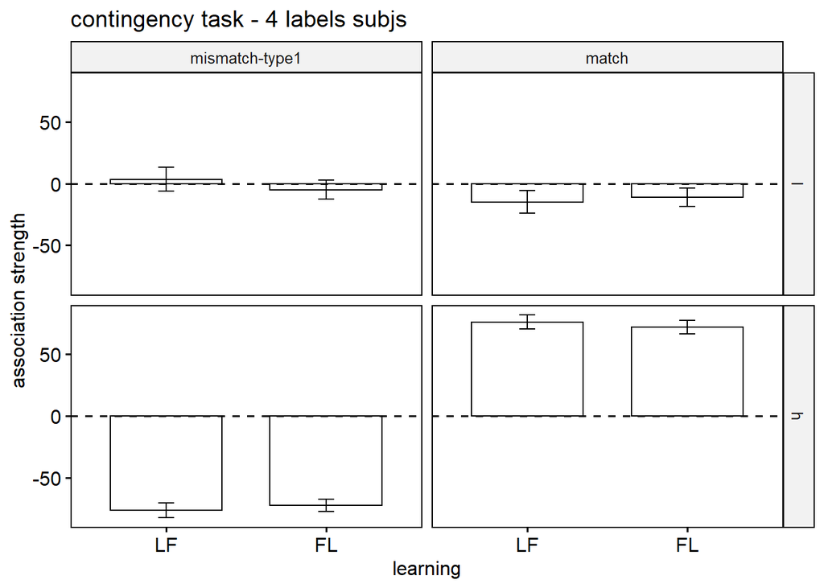

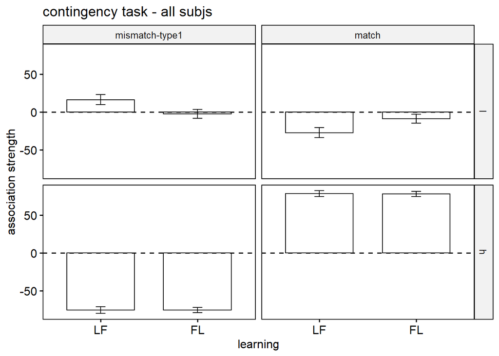

## Experiment 3bis

This is a continuation of the experiment 3, but with Prolific participants.

We exclude participants that score less than 80% in the control category (blue bims)

### raw means

How many participants do we have at the net of the exclusion criterion?

We have 77 participants in total. 45 for feature-label learning, and 32 for label-feature learning.

We have excluded the 29.4% of the total.

### 2AFC - 4 Labels task

In this task participants see one picture and have to choose the correct label among 4 candidates (dep,tob,wug,bim).

Key predictions are:

1. interaction between frequency and condition
2. FL > LF for low frequency

Secondary predictions:

3. main effect of frequency (note- will almost certainly find this, but it isn’t key to our hypotheses)
4. main effect of FL> LF

```r
picLab_prolific.clean$learning<- relevel(picLab_prolific.clean$learning, ref = "LF")
picLab_prolific.clean<-lizCenter(picLab_prolific.clean, listfname = list("learning", "correctFrequency"))

repFLO<-glmer(acc ~  correctFrequency.ct*learning.ct + (correctFrequency.ct|subjID),
              data = picLab_prolific.clean,
              family="binomial",
              control=glmerControl(optimizer = "bobyqa"))

output <- round(summary(repFLO)$coefficients,4)
output
```

```
##                                 Estimate Std. Error z value Pr(>|z|)
## (Intercept)                       0.4780     0.2411  1.9820   0.0475
## correctFrequency.ct              -3.5397     0.4483 -7.8958   0.0000
## learning.ct                      -0.6933     0.5126 -1.3526   0.1762
## correctFrequency.ct:learning.ct   0.2694     0.9504  0.2835   0.7768
```

- hypothesis D) **Higher accuracy in the high vs low frequency condition as evidenced by a main effect of frequency.**
- beta of the theory: 1.7
- beta of the current model: -3.5397 (std.error = 0.4483 )

BF for frequency:

```
## [1] 2.313746e+12
```

- hypothesis C) **higher accuracy in the feature-label learning condition, compared to label-feature learning-condition, as evidenced by a main effect of learning-condition.**
- beta of the theory: .66
- beta of the current model: -0.6933 (std.error = 0.5126) #note opposite direction

BF for learning:

```
## [1] 0.3111321
```

- hypothesis B) **A greater benefit of feature-label over label-feature for low frequency than for high frequency items, as evidenced by an interaction between frequency and learning-condition.**
- beta of the theory: 1.02
- beta of the current model: 0.2694 (std.error = 0.9504)

BF for the interaction between frequency and learning:

```
## [1] 0.807761
```

MODEL 2 FOR SIMPLE EFFECTS:

```r
repFLO_V2<-glmer(acc ~  correctFrequency.ct+ correctFrequency: learning.ct + (correctFrequency.ct|subjID),
                 data = picLab_prolific.clean,
                 family="binomial",
                 control=glmerControl(optimizer = "bobyqa"))

output_simpleEffect <- round(summary(repFLO_V2)$coefficients,4)
output_simpleEffect
```

```
##                                  Estimate Std. Error z value Pr(>|z|)
## (Intercept)                        0.4780     0.2412  1.9820   0.0475
## correctFrequency.ct               -3.5397     0.4483 -7.8957   0.0000
## correctFrequencyhigh:learning.ct  -0.8280     0.8462 -0.9785   0.3278
## correctFrequencylow:learning.ct   -0.5586     0.5111 -1.0929   0.2745
```

- hypothesis A.1) **Higher accuracy in the low frequency condition for the feature-label learning group compared to label-feature learning group, as evidenced by an effect of training-conditions for low-frequency test items.**
- beta of the theory: 1.17
- beta of the current model: -0.5586 (std.error = 0.5111)

BF for the simple effect of low frequency by learning:

```
## [1] 0.2091961
```

- hypothesis A.2) **Related to the hypothesis above, we test also whether there is an effect of training-conditions for high-frequency test items.**
- beta of the theory: .14
- beta of the current model: -0.828 (std.error = 0.8462)

BF for the simple effect of high frequency by learning:

```
## [1] 0.8638976
```

### 2AFC - 4 Pictures task

In this task participants had to choose the correct picture among 4 candidates for one label presented.

Key predictions are:

1. interaction between frequency and condition
2. FL > LF for low frequency

Secondary predictions:

3. main effect of frequency (note- will almost certainly find this, but it isn’t key to our hypotheses)
4. main effect of FL> LF

```r
labPic_prolific.clean$learning<- relevel(labPic_prolific.clean$learning, ref = "LF")
labPic_prolific.clean<-lizCenter(labPic_prolific.clean, listfname = list("learning", "correctFrequency"))

repFLO<-glmer(acc ~  correctFrequency.ct*learning.ct + (correctFrequency.ct|subjID),
              data = labPic_prolific.clean,
              family="binomial",
              control=glmerControl(optimizer = "bobyqa"))

output <- round(summary(repFLO)$coefficients,4)
output
```

```
##                                 Estimate Std. Error z value Pr(>|z|)
## (Intercept)                       0.3490     0.1408  2.4782   0.0132
## correctFrequency.ct              -4.3206     0.4653 -9.2861   0.0000
## learning.ct                      -0.6052     0.2562 -2.3620   0.0182
## correctFrequency.ct:learning.ct   0.3839     0.9065  0.4235   0.6719
```

- hypothesis D) **Higher accuracy in the high vs low frequency condition as evidenced by a main effect of frequency.**
- beta of the theory: 1.7
- beta of the current model: -4.3206 (std.error = 0.4653)

BF for frequency:

```
## [1] 1.380131e+17
```

- hypothesis C) **higher accuracy in the feature-label learning condition, compared to label-feature learning-condition, as evidenced by a main effect of learning-condition.**
- beta of the theory: .66
- beta of the current model: -0.6052 (std.error = 0.2562)

BF for learning:

```
## [1] 0.1148537
```

- hypothesis B) **A greater benefit of feature-label over label-feature for low frequency than for high frequency items, as evidenced by an interaction between frequency and learning-condition.**
- beta of the theory: 1.02
- beta of the current model: 0.3839 (std.error = 0.9065)

BF for the interaction between learning and frequency:

```
## [1] 0.8685176
```

MODEL 2 FOR SIMPLE EFFECTS:

```r
repFLO_V2<-glmer(acc ~  correctFrequency.ct+ correctFrequency: learning.ct  + (correctFrequency.ct|subjID),
                 data = labPic_prolific.clean,
                 family="binomial",
                 control=glmerControl(optimizer = "bobyqa"))

output_simpleEffect <- round(summary(repFLO_V2)$coefficients,4)
output_simpleEffect
```

```
##                                  Estimate Std. Error z value Pr(>|z|)
## (Intercept)                        0.3490     0.1408  2.4781   0.0132
## correctFrequency.ct               -4.3206     0.4653 -9.2853   0.0000
## correctFrequencyhigh:learning.ct  -0.7972     0.6191 -1.2876   0.1979
## correctFrequencylow:learning.ct   -0.4132     0.3989 -1.0360   0.3002
```

- hypothesis A.1) **Higher accuracy in the low frequency condition for the feature-label learning group compared to label-feature learning group, as evidenced by an effect of training-conditions for low-frequency test items.**
- beta of the theory: 1.17
- beta of the current model: -0.4132 (std.error = 0.3989)

BF for the simple effect of learning for low frequency items:

```
## [1] 0.1708581
```

- hypothesis A.2) **Related to the hypothesis above, we test also whether there is an effect of training-conditions for high-frequency test items.**
- beta of the theory: .14
- beta of the current model: -0.7972 (std.error = 0.6191)

BF for the simple effect of learning for high frequency items:

```
## [1] 0.7755812
```

### Both 2AFC tasks together

```
##                                 Estimate Std. Error  z value Pr(>|z|)
## (Intercept)                       0.3831     0.1316   2.9109   0.0036
## correctFrequency.ct              -3.9306     0.3222 -12.1978   0.0000
## learning.ct                      -0.6050     0.2572  -2.3522   0.0187
## correctFrequency.ct:learning.ct   0.5274     0.6387   0.8258   0.4089
```

- hypothesis D) **Higher accuracy in the high vs low frequency condition as evidenced by a main effect of frequency.**
- beta of the theory: 1.7
- beta of the current model: -3.9306 (std.error = 0.3222)

BF for frequency:

```
## [1] 5.832231e+30
```

- hypothesis C) **higher accuracy in the feature-label learning condition, compared to label-feature learning-condition, as evidenced by a main effect of learning-condition.**
- beta of the theory: .66
- beta of the current model: -0.605 (std.error = 0.2572)

BF for learning:

```
## [1] 0.1156516
```

- hypothesis B) **A greater benefit of feature-label over label-feature for low frequency than for high frequency items, as evidenced by an interaction between frequency and learning-condition.**
- beta of the theory: 1.02
- beta of the current model: 0.5274 (std.error = 0.6387)

BF for the interaction between learning and frequency:

```
## [1] 1.022742
```

MODEL 2 FOR SIMPLE EFFECTS:

```r
repFLO_V2<-glmer(acc ~  correctFrequency.ct+ correctFrequency: learning.ct  + (correctFrequency.ct|subjID),
                 data = FLO_tasks_expe3b,
                 family="binomial",
                 control=glmerControl(optimizer = "bobyqa"))

output_simpleEffect <- round(summary(repFLO_V2)$coefficients,4)
output_simpleEffect
```

```
##                                  Estimate Std. Error  z value Pr(>|z|)
## (Intercept)                        0.3831     0.1316   2.9109   0.0036
## correctFrequency.ct               -3.9306     0.3223 -12.1966   0.0000
## correctFrequencyhigh:learning.ct  -0.8687     0.4819  -1.8028   0.0714
## correctFrequencylow:learning.ct   -0.3413     0.3229  -1.0569   0.2906
```

- hypothesis A.1) **Higher accuracy in the low frequency condition for the feature-label learning group compared to label-feature learning group, as evidenced by an effect of training-conditions for low-frequency test items.**
- beta of the theory: 1.17
- beta of the current model: -0.3413 (std.error = 0.3229)

BF of the simple effect of low frequency by learning:

```
## [1] 0.1384055
```

- hypothesis A.2) **Related to the hypothesis above, we test also whether there is an effect of training-conditions for high-frequency test items.**
- beta of the theory: .14
- beta of the current model: -0.8687 (std.error = 0.4819)

BF of the simple effect of high frequency by learning:

```
## [1] 0.6533164
```

### contingency task

The possible label-fribble combinations are of two types:

- match: label-fribble pair presented is 100% correct for both high and low frequency conditions.
- mismatch: Items label is incorrect for this fribble type but the fribble has a high salience feature (shape) which is with the label.

For this task we are interested in just the match + mismatch data, and the following predictions:

The predictions are:

1. high: match: higher positive weight in LF (+ve coefficient) [LARGER EFFECT]
2. low match: higher positive weight in FL (-ve coeffficient) [SMALLER EFFECT]
3. high mismatch: FL larger negative weight than LF (+ve coefficient)
4. low mismatch: FL larger negative weight, LF positive (+ve coefficient) [LARGER EFFECT]

All of these are predicted from the computational model - however it is most likely that we will see the effects in (1) and (4) since these are largest.

```r
contingency_prolific$trialType<- as.factor(contingency_prolific$trialType)
contingency_prolific$frequency<- as.factor(contingency_prolific$frequency)
contingency_prolific$subjID<- as.factor(contingency_prolific$subjID)
contingency_prolific$fribbleID<- as.factor(contingency_prolific$fribbleID)

relevel(contingency_prolific$trialType, ref = "mismatch-type1")->contingency_prolific$trialType
relevel(contingency_prolific$learning, ref = "LF")->contingency_prolific$learning
relevel(contingency_prolific$frequency, ref = "l")->contingency_prolific$frequency

contingency_prolific<-lizCenter(contingency_prolific, listfname = list("learning", "frequency", "trialType"))

lm1<- lmerTest::lmer(resp ~  frequency:trialType:learning + frequency.ct * trialType.ct  + (frequency.ct|subjID), data = contingency_prolific)
```

```
## fixed-effect model matrix is rank deficient so dropping 4 columns / coefficients
```

```
## boundary (singular) fit: see ?isSingular
```

```r
car::Anova(lm1)
```

```
## Analysis of Deviance Table (Type II Wald chisquare tests)
##
## Response: resp
##                                  Chisq Df Pr(>Chisq)
## frequency.ct                    4.3017  1    0.03807 *
## trialType.ct                   80.7324  1  < 2.2e-16 ***
## frequency.ct:trialType.ct    1530.1139  1  < 2.2e-16 ***
## frequency:trialType:learning   26.1782  4  2.913e-05 ***
## ---
## Signif. codes:  0 '***' 0.001 '**' 0.01 '*' 0.05 '.' 0.1 ' ' 1
```

```r
output<-round(summary(lm1)$coefficients,4)
kableExtra::kable(output)
```

|  | Estimate | Std. Error | df | t value | Pr(>\|t\|) |
| --- | --- | --- | --- | --- | --- |
| (Intercept) | -2.2325 | 1.9808 | 75.4422 | -1.1271 | 0.2633 |
| frequency.ct | 4.7935 | 2.4933 | 989.0786 | 1.9225 | 0.0548 |
| trialType.ct | 21.9357 | 2.4659 | 4457.0202 | 8.8957 | 0.0000 |
| frequency.ct:trialType.ct | 192.9138 | 4.9318 | 4457.2317 | 39.1167 | 0.0000 |
| frequencyl:trialTypemismatch-type1:learningLF | -9.5281 | 4.6663 | 182.0099 | -2.0419 | 0.0426 |
| frequencyh:trialTypemismatch-type1:learningLF | -10.2239 | 4.3656 | 244.6387 | -2.3419 | 0.0200 |
| frequencyl:trialTypematch:learningLF | 0.6880 | 4.6622 | 181.6795 | 0.1476 | 0.8828 |
| frequencyh:trialTypematch:learningLF | 13.8380 | 4.3573 | 242.8519 | 3.1758 | 0.0017 |

- Hypothesis D) **Higher ratings for match compared to the mismatch trials.**

beta of the theory: 53.78

beta of the current model: 21.9357 (std.error = 2.4659)

BF for main effect of type:

```
## [1] 1.288364e+16
```

- Hypothesis E) **Higher ratings for high frequency match- than low frequency match trials, but lower ratings for high frequency mismatch than low frequency mismatch, as evidenced by an interaction between frequency condition and type.**
- beta of the theory: 83.61 #note here I reverse the sign with *-1
- beta of the current model: 192.9138 (std.error = 4.9318)

BF for interaction frequency by type:

```
## [1] Inf
```

- Hypothesis C.1) **High frequency – match: stronger learning- in label-feature (evidenced by positive effect of learning-condition i.e. higher ratings in label feature than feature label))**
- beta of the theory: 16
- beta of the current model: 13.838 (std.error = 4.3573)

BF for Simple effect of learning for frequency high - match:

```
## [1] 57.30132
```

- hypothesis C.2) **Low frequency – match: stronger learning in feature-label (evidenced by negative effect of learning-condition i.e. higher ratings in feature-label feature).**
- beta of the theory: -16 (note negative sign)
- beta of the current model: 0.688 (std.error = 4.6622)

BF Simple effect of learning for frequency low - match:

```
## [1] 0.2522308
```

- Hypothesis C.3) **High frequency – mismatch-type: stronger learning in feature-label (evidenced by positive effect of learning-condition i.e. higher ratings in label-feature than feature-label).**
- beta of the theory: 16
- beta of the current model: -10.2239 (std.error = 4.3656) – note here the opposite sign

BF Simple effect of learning for frequency high - mismatch:

```
## [1] 0.0824746
```

- Hypothesis C.4) **Low frequency – mismatch-type: stronger learning in feature-label (evidenced by positive effect of learning-condition i.e. higher ratings in label-feature than feature-label).**
- beta of the theory: 16
- beta of the current model: -9.5281 (std.error = 4.6663) – note here the opposite sign

BF Simple effect of learning for frequency low - mismatch:

```
## [1] 0.09735864
```

### Plot experiment 3bis

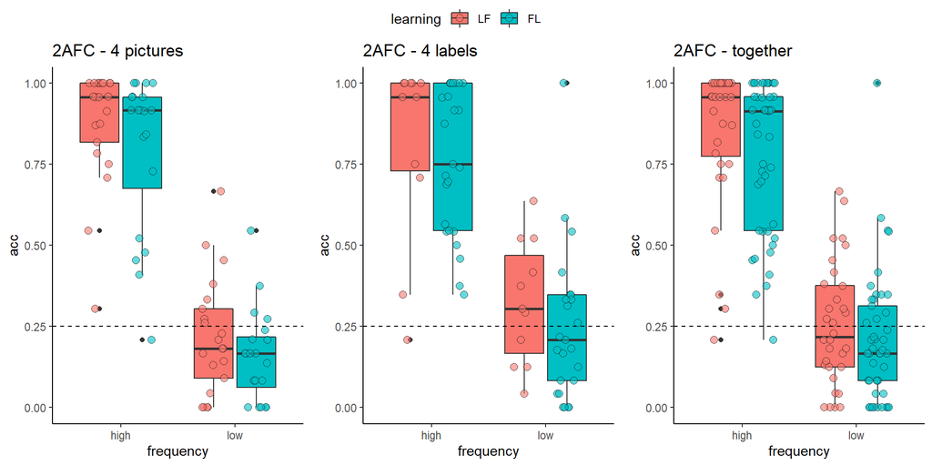

```r
contingency_prolific %>%
  filter(generalizationTest=="labPic") %>%
  group_by(learning, frequency, trialType) %>%
  summarise(mean=mean(resp, na.rm = T),
            sd=sd(resp, na.rm = T),
            count = n()) %>%
  mutate(se = sd / sqrt(count),
         lower_ci = lower_ci(mean, se, count),
         upper_ci = upper_ci(mean, se, count))
```

```
## # A tibble: 8 x 9
## # Groups:   learning, frequency [4]
##   learning frequency trialType       mean    sd count    se lower_ci upper_ci
##   <fct>    <fct>     <fct>          <dbl> <dbl> <int> <dbl>    <dbl>    <dbl>
## 1 LF       l         mismatch-type1  35.3  72.4   315  4.08     27.3     43.3
## 2 LF       l         match          -52.9  62.5   315  3.52    -59.8    -46.0
## 3 LF       h         mismatch-type1 -73.7  54.2   315  3.05    -79.7    -67.7
## 4 LF       h         match           77.4  49.5   315  2.79     71.9     82.8
## 5 FL       l         mismatch-type1  42.0  65.3   289  3.84     34.4     49.5
## 6 FL       l         match          -54.6  61.8   292  3.62    -61.7    -47.5
## 7 FL       h         mismatch-type1 -57.3  63.9   292  3.74    -64.7    -49.9
## 8 FL       h         match           64.0  54.1   291  3.17     57.7     70.2
```

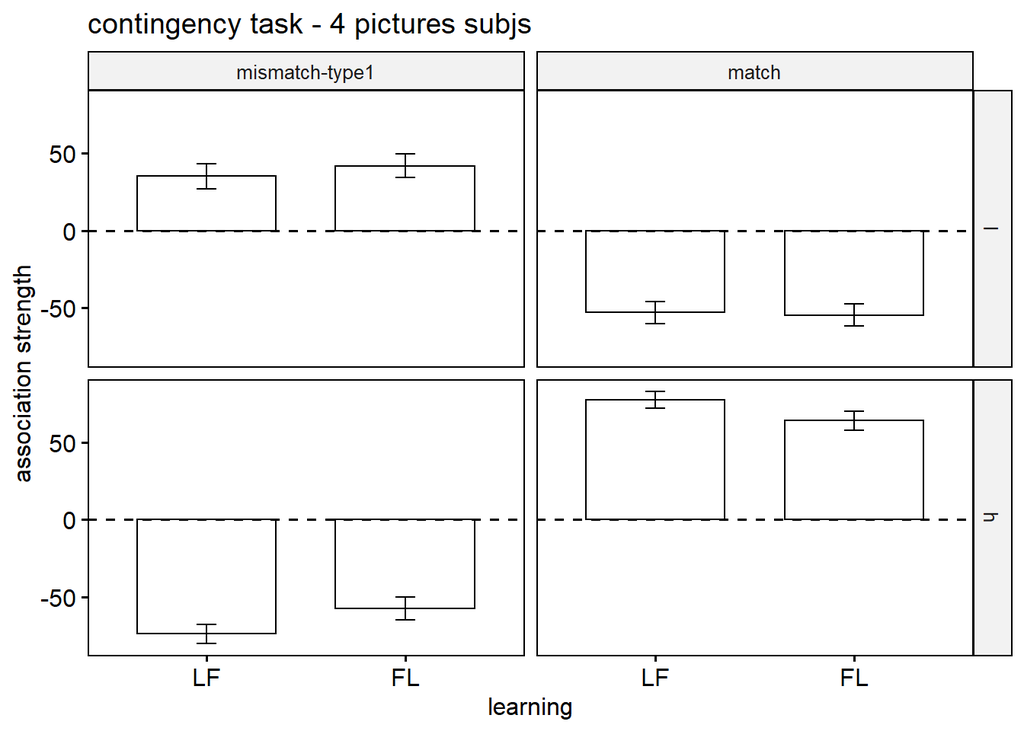

```r
contingency_prolific %>%
  filter(generalizationTest=="picLab") %>%
  group_by(learning, frequency, trialType) %>%
  summarise(mean=mean(resp, na.rm = T),
            sd=sd(resp, na.rm = T),
            count = n()) %>%
  mutate(se = sd / sqrt(count),
         lower_ci = lower_ci(mean, se, count),
         upper_ci = upper_ci(mean, se, count))
```

```
## # A tibble: 8 x 9
## # Groups:   learning, frequency [4]
##   learning frequency trialType         mean    sd count    se lower_ci upper_ci
##   <fct>    <fct>     <fct>            <dbl> <dbl> <int> <dbl>    <dbl>    <dbl>
## 1 LF       l         mismatch-type1   0.273  72.4   165  5.64    -10.9    11.4
## 2 LF       l         match          -18.7    74.4   165  5.79    -30.2    -7.29
## 3 LF       h         mismatch-type1 -60.7    67.2   165  5.23    -71.0   -50.3
## 4 LF       h         match           65.3    61.4   165  4.78     55.9    74.7
## 5 FL       l         mismatch-type1  25.5    72.2   375  3.73     18.1    32.8
## 6 FL       l         match          -32.0    71.5   375  3.69    -39.3   -24.8
## 7 FL       h         mismatch-type1 -60.5    56.9   375  2.94    -66.2   -54.7
## 8 FL       h         match           55.7    58.5   375  3.02     49.7    61.6
```

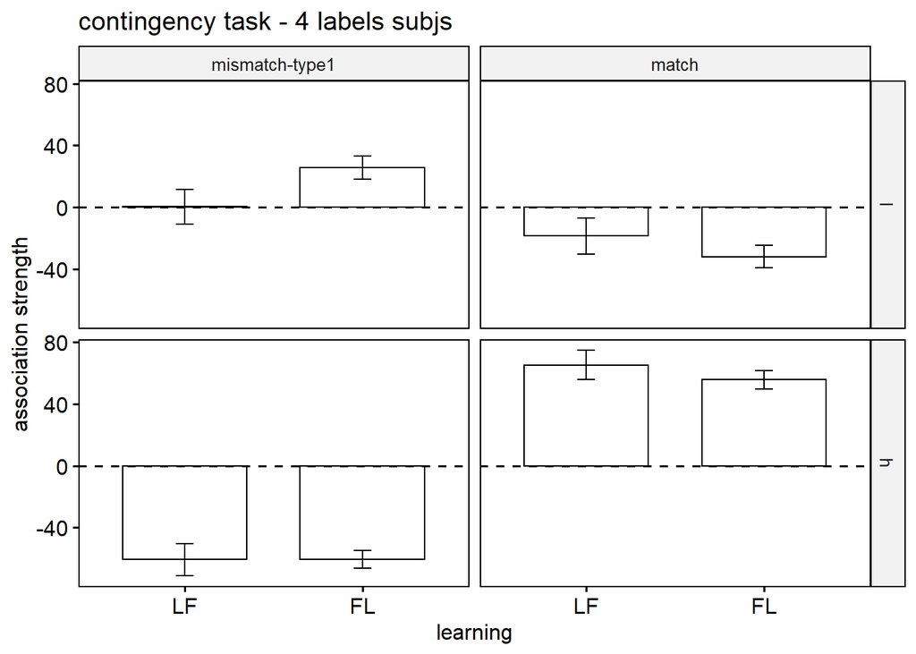

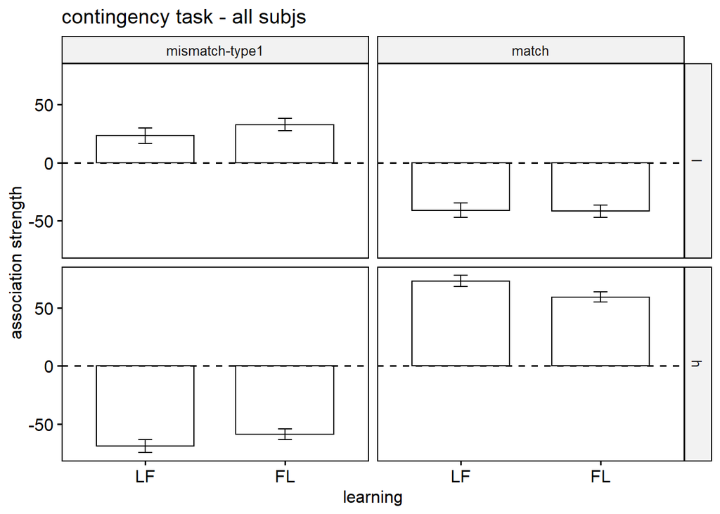

## Experiment 4

In this experiment we merge the data of the experiment 3 (Tubingen data) and experiment 3bis (Prolific data).

### raw means

How many participants do we have at the net of the exclusion criterion?

```r
listSubj.labPic <-aggregate(acc ~ subjID+group, labPic_expe4[labPic_expe4$label=='bim',] ,mean)
badSubj <-unique(listSubj.labPic[listSubj.labPic$acc<.8,]$subjID);

listSubj.picLab <-aggregate(acc ~ subjID+group, picLab_expe4[picLab_expe4$trialType=='control',] ,mean)
badSubj2 <-unique(listSubj.picLab[listSubj.picLab$acc<.8,]$subjID);

propBadSubjs <-round((length(badSubj)+length(badSubj2)) / (nrow(listSubj.labPic)+nrow(listSubj.picLab)) *100, 1)

#remove bad subjects
labPic.clean_expe4 <- labPic_expe4[!(labPic_expe4$subjID %in% badSubj),];
picLab.clean_expe4 <- picLab_expe4[!(picLab_expe4$subjID %in% badSubj2),];
contingency_expe4 <-contingency_expe4[!(contingency_expe4$subjID %in% badSubj),]
contingency_expe4 <-contingency_expe4[!(contingency_expe4$subjID %in% badSubj2),]


#remove control trials
labPic.clean_expe4 <- labPic.clean_expe4[labPic.clean_expe4$label!='bim',]
picLab.clean_expe4 <- picLab.clean_expe4[picLab.clean_expe4$trialType!='control',]

picLab.clean_expe4<-droplevels(picLab.clean_expe4)
labPic.clean_expe4<-droplevels(labPic.clean_expe4)


#how many participants per learning?
#group1
fl1<-length(unique(labPic.clean_expe4[labPic.clean_expe4$learning=="FL",]$subjID))
#group2
lf1<-length(unique(labPic.clean_expe4[labPic.clean_expe4$learning=="LF",]$subjID))
#group3
fl2<-length(unique(picLab.clean_expe4[picLab.clean_expe4$learning=="FL",]$subjID))
#group4
lf2<-length(unique(picLab.clean_expe4[picLab.clean_expe4$learning=="LF",]$subjID))

totSubjs <- length(unique(picLab.clean_expe4$subjID)) + length(unique(labPic.clean_expe4$subjID))
```

We have 155 participants in total. 89 for feature-label learning, and 66 for label-feature learning.

We have excluded the 25.5% of the total.

### 2AFC - 4 Labels task

In this task participants see one picture and have to choose the correct label among 4 candidates (dep,tob,wug,bim).

Key predictions are:

1. interaction between frequency and condition
2. FL > LF for low frequency

Secondary predictions:

3. main effect of frequency (note- will almost certainly find this, but it isn’t key to our hypotheses)
4. main effect of FL> LF

```r
picLab.clean_expe4$learning<- relevel(picLab.clean_expe4$learning, ref = "LF")
picLab.clean_expe4<-lizCenter(picLab.clean_expe4, listfname = list("learning", "correctFrequency"))

repFLO<-glmer(acc ~  correctFrequency.ct*learning.ct + (correctFrequency.ct|subjID),
              data = picLab.clean_expe4,
              family="binomial",
              control=glmerControl(optimizer = "bobyqa"))

output <- round(summary(repFLO)$coefficients,4)
output
```

```
##                                 Estimate Std. Error  z value Pr(>|z|)
## (Intercept)                       0.9840     0.1839   5.3522   0.0000
## correctFrequency.ct              -3.6918     0.3198 -11.5450   0.0000
## learning.ct                      -0.4271     0.3592  -1.1888   0.2345
## correctFrequency.ct:learning.ct   0.2939     0.6126   0.4798   0.6314
```

- hypothesis D) **Higher accuracy in the high vs low frequency condition as evidenced by a main effect of frequency.**
- beta of the theory: 1.7
- beta of the current model: -3.6918 (std.error = 0.3198 )

BF for frequency:

```
## [1] 3.283326e+27
```

- hypothesis C) **higher accuracy in the feature-label learning condition, compared to label-feature learning-condition, as evidenced by a main effect of learning-condition.**
- beta of the theory: .66
- beta of the current model: -0.4271 (std.error = 0.3592) #note opposite direction

BF for learning:

```
## [1] 0.2458801
```

- hypothesis B) **A greater benefit of feature-label over label-feature for low frequency than for high frequency items, as evidenced by an interaction between frequency and learning-condition.**
- beta of the theory: 1.02
- beta of the current model: 0.2939 (std.error = 0.6126)

BF for the interaction between frequency and learning:

```
## [1] 0.7351041
```

MODEL 2 FOR SIMPLE EFFECTS:

```r
repFLO_V2<-glmer(acc ~  correctFrequency.ct+ correctFrequency: learning.ct + (correctFrequency.ct|subjID),
                 data = picLab.clean_expe4,
                 family="binomial",
                 control=glmerControl(optimizer = "bobyqa"))

output_simpleEffect <- round(summary(repFLO_V2)$coefficients,4)
output_simpleEffect
```

```
##                                  Estimate Std. Error  z value Pr(>|z|)
## (Intercept)                        0.9840     0.1839   5.3520   0.0000
## correctFrequency.ct               -3.6918     0.3198 -11.5437   0.0000
## correctFrequencyhigh:learning.ct  -0.5740     0.5603  -1.0245   0.3056
## correctFrequencylow:learning.ct   -0.2801     0.3632  -0.7711   0.4406
```

- hypothesis A.1) **Higher accuracy in the low frequency condition for the feature-label learning group compared to label-feature learning group, as evidenced by an effect of training-conditions for low-frequency test items.**
- beta of the theory: 1.17
- beta of the current model: -0.2801 (std.error = 0.3632)

BF for the simple effect of low frequency by learning:

```
## [1] 0.1796133
```

- hypothesis A.2) **Related to the hypothesis above, we test also whether there is an effect of training-conditions for high-frequency test items.**
- beta of the theory: .14
- beta of the current model: -0.574 (std.error = 0.5603)

BF for the simple effect of high frequency by learning:

```
## [1] 0.7918624
```

### 2AFC - 4 Pictures task

In this task participants had to choose the correct picture among 4 candidates for one label presented.

Key predictions are:

1. interaction between frequency and condition
2. FL > LF for low frequency

Secondary predictions:

3. main effect of frequency (note- will almost certainly find this, but it isn’t key to our hypotheses)
4. main effect of FL> LF

```r
labPic.clean_expe4$learning<- relevel(labPic.clean_expe4$learning, ref = "LF")
labPic.clean_expe4<-lizCenter(labPic.clean_expe4, listfname = list("learning", "correctFrequency"))

repFLO<-glmer(acc ~  correctFrequency.ct*learning.ct + (correctFrequency.ct|subjID),
              data = labPic.clean_expe4,
              family="binomial",
              control=glmerControl(optimizer = "bobyqa"))

output <- round(summary(repFLO)$coefficients,4)
output
```

```
##                                 Estimate Std. Error  z value Pr(>|z|)
## (Intercept)                       0.4717     0.1346   3.5048   0.0005
## correctFrequency.ct              -4.4158     0.3387 -13.0390   0.0000
## learning.ct                       0.1182     0.2569   0.4602   0.6454
## correctFrequency.ct:learning.ct   0.6399     0.6593   0.9705   0.3318
```

- hypothesis D) **Higher accuracy in the high vs low frequency condition as evidenced by a main effect of frequency.**
- beta of the theory: 1.7
- beta of the current model: -4.4158 (std.error = 0.3387)

BF for frequency:

```
## [1] 1.235307e+35
```

- hypothesis C) **higher accuracy in the feature-label learning condition, compared to label-feature learning-condition, as evidenced by a main effect of learning-condition.**
- beta of the theory: .66
- beta of the current model: 0.1182 (std.error = 0.2569)

BF for learning:

```
## [1] 0.5305737
```

- hypothesis B) **A greater benefit of feature-label over label-feature for low frequency than for high frequency items, as evidenced by an interaction between frequency and learning-condition.**
- beta of the theory: 1.02
- beta of the current model: 0.6399 (std.error = 0.6593)

BF for the interaction between learning and frequency:

```
## [1] 1.194082
```

MODEL 2 FOR SIMPLE EFFECTS:

```r
repFLO_V2<-glmer(acc ~  correctFrequency.ct+ correctFrequency: learning.ct  + (correctFrequency.ct|subjID),
                 data = labPic.clean_expe4,
                 family="binomial",
                 control=glmerControl(optimizer = "bobyqa"))

output_simpleEffect <- round(summary(repFLO_V2)$coefficients,4)
output_simpleEffect
```

```
##                                  Estimate Std. Error  z value Pr(>|z|)
## (Intercept)                        0.4717     0.1346   3.5049   0.0005
## correctFrequency.ct               -4.4158     0.3387 -13.0385   0.0000
## correctFrequencyhigh:learning.ct  -0.2017     0.4374  -0.4611   0.6447
## correctFrequencylow:learning.ct    0.4382     0.3976   1.1022   0.2704
```

- hypothesis A.1) **Higher accuracy in the low frequency condition for the feature-label learning group compared to label-feature learning group, as evidenced by an effect of training-conditions for low-frequency test items.**
- beta of the theory: 1.17
- beta of the current model: 0.4382 (std.error = 0.3976)

BF for the simple effect of learning for low frequency items:

```
## [1] 0.9387015
```

- hypothesis A.2) **Related to the hypothesis above, we test also whether there is an effect of training-conditions for high-frequency test items.**
- beta of the theory: .14
- beta of the current model: -0.2017 (std.error = 0.4374)

BF for the simple effect of learning for high frequency items:

```
## [1] 0.8431338
```

### Both 2AFC tasks together

```
##                                 Estimate Std. Error  z value Pr(>|z|)
## (Intercept)                       0.7387     0.1162   6.3546   0.0000
## correctFrequency.ct              -4.0098     0.2341 -17.1266   0.0000
## learning.ct                      -0.1244     0.2227  -0.5585   0.5765
## correctFrequency.ct:learning.ct   0.5521     0.4492   1.2290   0.2191
```

- hypothesis D) **Higher accuracy in the high vs low frequency condition as evidenced by a main effect of frequency.**
- beta of the theory: 1.7
- beta of the current model: -4.0098 (std.error = 0.2341)

BF for frequency:

```
## [1] 9.075147e+61
```

- hypothesis C) **higher accuracy in the feature-label learning condition, compared to label-feature learning-condition, as evidenced by a main effect of learning-condition.**
- beta of the theory: .66
- beta of the current model: -0.1244 (std.error = 0.2227)

BF for learning:

```
## [1] 0.2209808
```

- hypothesis B) **A greater benefit of feature-label over label-feature for low frequency than for high frequency items, as evidenced by an interaction between frequency and learning-condition.**
- beta of the theory: 1.02
- beta of the current model: 0.5521 (std.error = 0.4492)

BF for the interaction between learning and frequency:

```
## [1] 1.311488
```

MODEL 2 FOR SIMPLE EFFECTS:

```r
repFLO_V2<-glmer(acc ~  correctFrequency.ct+ correctFrequency: learning.ct  + (correctFrequency.ct|subjID),
                 data = FLO_tasks_expe4,
                 family="binomial",
                 control=glmerControl(optimizer = "bobyqa"))

output_simpleEffect <- round(summary(repFLO_V2)$coefficients,4)
output_simpleEffect
```

```
##                                  Estimate Std. Error  z value Pr(>|z|)
## (Intercept)                        0.7387     0.1162   6.3542   0.0000
## correctFrequency.ct               -4.0098     0.2342 -17.1232   0.0000
## correctFrequencyhigh:learning.ct  -0.4004     0.3521  -1.1371   0.2555
## correctFrequencylow:learning.ct    0.1517     0.2761   0.5492   0.5829
```

- hypothesis A.1) **Higher accuracy in the low frequency condition for the feature-label learning group compared to label-feature learning group, as evidenced by an effect of training-conditions for low-frequency test items.**
- beta of the theory: 1.17
- beta of the current model: 0.1517 (std.error = 0.2761)

BF of the simple effect of low frequency by learning:

```
## [1] 0.371215
```

- hypothesis A.2) **Related to the hypothesis above, we test also whether there is an effect of training-conditions for high-frequency test items.**
- beta of the theory: .14
- beta of the current model: -0.4004 (std.error = 0.3521)

BF of the simple effect of high frequency by learning:

```
## [1] 0.6670159
```

### contingency task

The possible label-fribble combinations are of two types:

- match: label-fribble pair presented is 100% correct for both high and low frequency conditions.
- mismatch: Items label is incorrect for this fribble type but the fribble has a high salience feature (shape) which is with the label.

For this task we are interested in just the match + mismatch data, and the following predictions:

The predictions are:

1. high: match: higher positive weight in LF (+ve coefficient) [LARGER EFFECT]
2. low match: higher positive weight in FL (-ve coeffficient) [SMALLER EFFECT]
3. high mismatch: FL larger negative weight than LF (+ve coefficient)
4. low mismatch: FL larger negative weight, LF positive (+ve coefficient) [LARGER EFFECT]

All of these are predicted from the computational model - however it is most likely that we will see the effects in (1) and (4) since these are largest.

```r
contingency_expe4$trialType<- as.factor(contingency_expe4$trialType)
contingency_expe4$frequency<- as.factor(contingency_expe4$frequency)
contingency_expe4$subjID<- as.factor(contingency_expe4$subjID)
contingency_expe4$fribbleID<- as.factor(contingency_expe4$fribbleID)

relevel(contingency_expe4$trialType, ref = "mismatch-type1")->contingency_expe4$trialType
relevel(contingency_expe4$learning, ref = "LF")->contingency_expe4$learning
relevel(contingency_expe4$frequency, ref = "l")->contingency_expe4$frequency

contingency_expe4<-lizCenter(contingency_expe4, listfname = list("learning", "frequency", "trialType"))

lm1<- lmerTest::lmer(resp ~  frequency:trialType:learning + frequency.ct * trialType.ct  + (frequency.ct|subjID), data = contingency_expe4)
```

```
## fixed-effect model matrix is rank deficient so dropping 4 columns / coefficients
```

```
## boundary (singular) fit: see ?isSingular
```

```r
car::Anova(lm1)
```

```
## Analysis of Deviance Table (Type II Wald chisquare tests)
##
## Response: resp
##                                 Chisq Df Pr(>Chisq)
## frequency.ct                   10.351  1   0.001294 **
## trialType.ct                  745.157  1  < 2.2e-16 ***
## frequency.ct:trialType.ct    2521.252  1  < 2.2e-16 ***
## frequency:trialType:learning   23.449  4   0.000103 ***
## ---
## Signif. codes:  0 '***' 0.001 '**' 0.01 '*' 0.05 '.' 0.1 ' ' 1
```

```r
output<-round(summary(lm1)$coefficients,4)
kableExtra::kable(output)
```

|  | Estimate | Std. Error | df | t value | Pr(>\|t\|) |
| --- | --- | --- | --- | --- | --- |
| (Intercept) | -2.2774 | 1.2318 | 155.7009 | -1.8488 | 0.0664 |
| frequency.ct | 5.7487 | 1.8155 | 811.7031 | 3.1664 | 0.0016 |
| trialType.ct | 47.5673 | 1.7595 | 8998.8706 | 27.0353 | 0.0000 |
| frequency.ct:trialType.ct | 176.6917 | 3.5189 | 8999.0021 | 50.2121 | 0.0000 |
| frequencyl:trialTypemismatch-type1:learningLF | 4.3664 | 3.1690 | 405.8689 | 1.3778 | 0.1690 |
| frequencyh:trialTypemismatch-type1:learningLF | -5.1536 | 2.8621 | 857.6526 | -1.8006 | 0.0721 |
| frequencyl:trialTypematch:learningLF | -8.4907 | 3.1678 | 405.6915 | -2.6803 | 0.0077 |
| frequencyh:trialTypematch:learningLF | 7.3358 | 2.8599 | 855.1505 | 2.5651 | 0.0105 |

- Hypothesis D) **Higher ratings for match compared to the mismatch trials.**

beta of the theory: 53.78

beta of the current model: 47.5673 (std.error = 1.7595)

BF for main effect of type:

```
## [1] 2.251777e+157
```

- Hypothesis E) **Higher ratings for high frequency match- than low frequency match trials, but lower ratings for high frequency mismatch than low frequency mismatch, as evidenced by an interaction between frequency condition and type.**
- beta of the theory: 83.61 #note here I reverse the sign with *-1
- beta of the current model: 176.6917 (std.error = 3.5189)

BF for interaction frequency by type:

```
## [1] Inf
```

- Hypothesis C.1) **High frequency – match: stronger learning- in label-feature (evidenced by positive effect of learning-condition i.e. higher ratings in label feature than feature label))**
- beta of the theory: 16
- beta of the current model: 7.3358 (std.error = 2.8599)

BF for Simple effect of learning for frequency high - match:

```
## [1] 8.465173
```

- hypothesis C.2) **Low frequency – match: stronger learning in feature-label (evidenced by negative effect of learning-condition i.e. higher ratings in feature-label feature).**
- beta of the theory: -16 (note negative sign)
- beta of the current model: -8.4907 (std.error = 3.1678)

BF Simple effect of learning for frequency low - match:

```
## [1] 12.24112
```

- Hypothesis C.3) **High frequency – mismatch-type: stronger learning in feature-label (evidenced by positive effect of learning-condition i.e. higher ratings in label-feature than feature-label).**
- beta of the theory: 16
- beta of the current model: -5.1536 (std.error = 2.8621) – note here the opposite sign

BF Simple effect of learning for frequency high - mismatch:

```
## [1] 0.06652442
```

BF Simple effect of learning for frequency low - mismatch:

```
## [1] 0.8833742
```

### Plot experiment 4

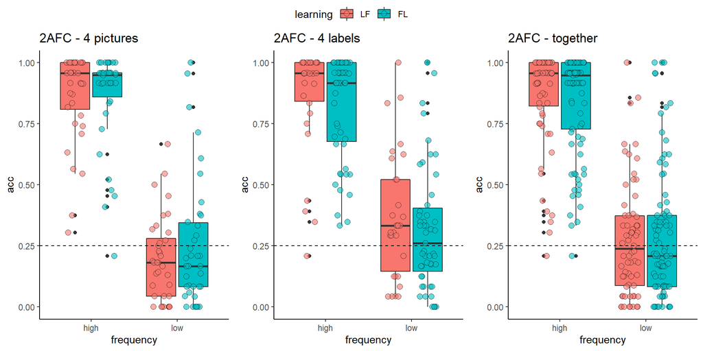

```r
contingency_expe4 %>%
  filter(generalizationTest=="labPic") %>%
  group_by(learning, frequency, trialType) %>%
  summarise(mean=mean(resp, na.rm = T),
            sd=sd(resp, na.rm = T),
            count = n()) %>%
  mutate(se = sd / sqrt(count),
         lower_ci = lower_ci(mean, se, count),
         upper_ci = upper_ci(mean, se, count))
```

```
## # A tibble: 8 x 9
## # Groups:   learning, frequency [4]
##   learning frequency trialType       mean    sd count    se lower_ci upper_ci
##   <fct>    <fct>     <fct>          <dbl> <dbl> <int> <dbl>    <dbl>    <dbl>
## 1 LF       l         mismatch-type1  34.0  68.9   540  2.97     28.2     39.9
## 2 LF       l         match          -48.8  64.8   540  2.79    -54.2    -43.3
## 3 LF       h         mismatch-type1 -74.1  52.1   540  2.24    -78.6    -69.7
## 4 LF       h         match           78.9  44.4   540  1.91     75.1     82.6
## 5 FL       l         mismatch-type1  22.5  72.5   559  3.07     16.5     28.5
## 6 FL       l         match          -31.2  73.6   562  3.10    -37.3    -25.1
## 7 FL       h         mismatch-type1 -68.6  55.2   562  2.33    -73.1    -64.0
## 8 FL       h         match           74.7  45.9   561  1.94     70.9     78.5
```

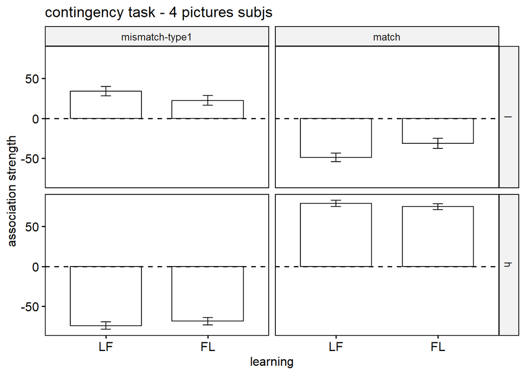

```r
contingency_expe4 %>%
  filter(generalizationTest=="picLab") %>%
  group_by(learning, frequency, trialType) %>%
  summarise(mean=mean(resp, na.rm = T),
            sd=sd(resp, na.rm = T),
            count = n()) %>%
  mutate(se = sd / sqrt(count),
         lower_ci = lower_ci(mean, se, count),
         upper_ci = upper_ci(mean, se, count))
```

```
## # A tibble: 8 x 9
## # Groups:   learning, frequency [4]
##   learning frequency trialType        mean    sd count    se lower_ci upper_ci
##   <fct>    <fct>     <fct>           <dbl> <dbl> <int> <dbl>    <dbl>    <dbl>
## 1 LF       l         mismatch-type1   2.25  77.8   450  3.67    -4.96     9.46
## 2 LF       l         match          -16.3   77.1   450  3.64   -23.5     -9.19
## 3 LF       h         mismatch-type1 -70.6   57.3   450  2.70   -75.9    -65.2
## 4 LF       h         match           72.3   53.7   450  2.53    67.3     77.2
## 5 FL       l         mismatch-type1   9.93  76.0   765  2.75     4.53    15.3
## 6 FL       l         match          -21.4   74.2   765  2.68   -26.7    -16.1
## 7 FL       h         mismatch-type1 -66.5   53.6   765  1.94   -70.3    -62.7
## 8 FL       h         match           64.0   56.5   765  2.04    60.0     68.0
```

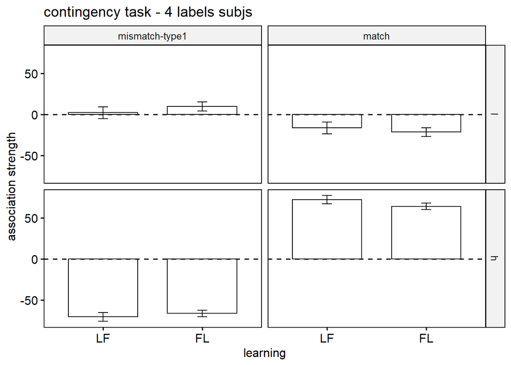

[figure not shown]